# Population Health and Economic Effects of Severe Weather Events: 1950 - 2011

Sharon Francisco

June 12, 2016

## Synopsis

This report identifies the weather events from 1950 to November 2011 that are most harmful with respect to population health and which have the greatest economic consequences. My hypothesis is that *TORNADO*s will be among the weather events with the greatest impacts because it is the one event that has been recorded since 1950. To investigate this hyptohesis, the U.S. National Oceanic and Atmospheric Administration’s (NOAA) storm database was used. From this data, I determined that *TORNADO*s were the most harmful to population health by a significant amount, followed by *HEAT*, *THUNDERSTORM/WIND*, *FLOOD*, AND *LIGHTNING*. *FLOOD*s had the greatest economic consequences, followed by *HURRICANE/TYPHOON*, *TORNADO*, *STORM SURGE/TIDE*, and *HAIL*. *TORNADO* and *FLOOD* were both in the top five events with the greatest health and economic impacts.

## Installing Packages and Loading Libraries

The packages used in the analysis are installed below.

```r
if(!require(dplyr, quietly = TRUE)) install.packages("dplyr")
```

```r
library(dplyr)
if(!require(ggplot2, quietly = TRUE)) install.packages("ggplot2")
library(ggplot2)
```

## Downloading, Loading, and Processing the Raw Data

The U.S. National Oceanic and Atmospheric Administration’s (NOAA) storm database was provided via the course web site: [Storm Data](https://d396qusza40orc.cloudfront.net/repdata%2Fdata%2FStormData.csv.bz2)

The following documents provide information about how some of the variables are constructed/defined:

- National Weather Service [Storm Data Documentation](https://d396qusza40orc.cloudfront.net/repdata%2Fpeer2_doc%2Fpd01016005curr.pdf)
- National Climatic Data Center Storm Events [FAQ](https://d396qusza40orc.cloudfront.net/repdata%2Fpeer2_doc%2FNCDC%20Storm%20Events-FAQ%20Page.pdf)

From the project instructions: The events in the database start in the year 1950 and end in November 2011. In the earlier years of the database there are generally fewer events recorded, most likely due to a lack of good records. More recent years should be considered more complete.

Additional information about the data base was found [here](https://www.ncdc.noaa.gov/stormevents/details.jsp):

- Tornado: From 1950 through 1954, only tornado events were recorded.
- Tornado, Thunderstorm Wind and Hail: From 1955 through 1992, only tornado, thunderstorm wind and hail events were keyed from paper publications into digital data. From 1993 to 1995, only tornado, thunderstorm wind and hail events have been extracted from the [Unformatted Text Files](https://www.ncdc.noaa.gov/stormevents/details.jsp?type=collection).
- All Event Types (48 from Directive 10-1605): from 1996 to present, 48 event types are recorded as defined in [NWS Directive 10-1605](https://www.ncdc.noaa.gov/stormevents/pd01016005curr.pdf)

Now I will download the relevant files.

```r
dataFileUrl <- "https://d396qusza40orc.cloudfront.net/repdata%2Fdata%2FStormData.csv.bz2"
variableFileUrl <- "https://d396qusza40orc.cloudfront.net/repdata%2Fpeer2_doc%2Fpd01016005curr.pdf"
faqUrl <- "https://d396qusza40orc.cloudfront.net/repdata%2Fpeer2_doc%2FNCDC%20Storm%20Events-FAQ%20Page.pdf"

download.file(dataFileUrl, "StormData.csv.bz2")
download.file(variableFileUrl, "variable_info.pdf")
download.file(faqUrl, "faq.pdf")

dateDownloaded <- date()
```

The data set was downloaded on Sat Jun 18 13:23:59 2016.

The data is comma-delimited, and missing values are coded as blank fields. The data set is read into R:

```r
stormData <- read.csv("StormData.csv.bz2", header = TRUE, na.strings = "")
dim(stormData)
```

```
## [1] 902297     37
```

There are 902,297 observations and 37 variables in the data set.

The first 10 rows of the data set are checked, and a summary of the data set is obtained:

```r
head(stormData, 10)
```

```
##    STATE__           BGN_DATE BGN_TIME TIME_ZONE COUNTY COUNTYNAME STATE
## 1        1  4/18/1950 0:00:00     0130       CST     97     MOBILE    AL
## 2        1  4/18/1950 0:00:00     0145       CST      3    BALDWIN    AL
## 3        1  2/20/1951 0:00:00     1600       CST     57    FAYETTE    AL
## 4        1   6/8/1951 0:00:00     0900       CST     89    MADISON    AL
## 5        1 11/15/1951 0:00:00     1500       CST     43    CULLMAN    AL
## 6        1 11/15/1951 0:00:00     2000       CST     77 LAUDERDALE    AL
## 7        1 11/16/1951 0:00:00     0100       CST      9     BLOUNT    AL
## 8        1  1/22/1952 0:00:00     0900       CST    123 TALLAPOOSA    AL
## 9        1  2/13/1952 0:00:00     2000       CST    125 TUSCALOOSA    AL
## 10       1  2/13/1952 0:00:00     2000       CST     57    FAYETTE    AL
##     EVTYPE BGN_RANGE BGN_AZI BGN_LOCATI END_DATE END_TIME COUNTY_END
## 1  TORNADO         0    <NA>       <NA>     <NA>     <NA>          0
## 2  TORNADO         0    <NA>       <NA>     <NA>     <NA>          0
## 3  TORNADO         0    <NA>       <NA>     <NA>     <NA>          0
```

[output cut: 40 more lines]

```r
summary(stormData)
```

```
##     STATE__                  BGN_DATE             BGN_TIME
##  Min.   : 1.0   5/25/2011 0:00:00:  1202   12:00:00 AM: 10163
##  1st Qu.:19.0   4/27/2011 0:00:00:  1193   06:00:00 PM:  7350
##  Median :30.0   6/9/2011 0:00:00 :  1030   04:00:00 PM:  7261
##  Mean   :31.2   5/30/2004 0:00:00:  1016   05:00:00 PM:  6891
##  3rd Qu.:45.0   4/4/2011 0:00:00 :  1009   12:00:00 PM:  6703
##  Max.   :95.0   4/2/2006 0:00:00 :   981   03:00:00 PM:  6700
##                 (Other)          :895866   (Other)    :857229
##    TIME_ZONE          COUNTY           COUNTYNAME         STATE
##  CST    :547493   Min.   :  0.0   JEFFERSON :  7840   TX     : 83728
##  EST    :245558   1st Qu.: 31.0   WASHINGTON:  7603   KS     : 53440
##  MST    : 68390   Median : 75.0   JACKSON   :  6660   OK     : 46802
##  PST    : 28302   Mean   :100.6   FRANKLIN  :  6256   MO     : 35648
##  AST    :  6360   3rd Qu.:131.0   LINCOLN   :  5937   IA     : 31069
##  HST    :  2563   Max.   :873.0   (Other)   :866412   NE     : 30271
##  (Other):  3631                   NA's      :  1589   (Other):621339
##                EVTYPE         BGN_RANGE           BGN_AZI
##  HAIL             :288661   Min.   :   0.000   N      : 86752
##  TSTM WIND        :219940   1st Qu.:   0.000   W      : 38446
##  THUNDERSTORM WIND: 82563   Median :   0.000   S      : 37558
##  TORNADO          : 60652   Mean   :   1.484   E      : 33178
##  FLASH FLOOD      : 54277   3rd Qu.:   1.000   NW     : 24041
##  FLOOD            : 25326   Max.   :3749.000   (Other):134990
##  (Other)          :170878                      NA's   :547332
##          BGN_LOCATI                  END_DATE             END_TIME
##  COUNTYWIDE   : 19680   4/27/2011 0:00:00:  1214   06:00:00 PM:  9802
##  Countywide   :   993   5/25/2011 0:00:00:  1196   05:00:00 PM:  8314
##  SPRINGFIELD  :   843   6/9/2011 0:00:00 :  1021   04:00:00 PM:  8104
##  SOUTH PORTION:   810   4/4/2011 0:00:00 :  1007   12:00:00 PM:  7483
##  NORTH PORTION:   784   5/30/2004 0:00:00:   998   11:59:00 PM:  7184
##  (Other)      :591444   (Other)          :653450   (Other)    :622432
##  NA's         :287743   NA's             :243411   NA's       :238978
##    COUNTY_END COUNTYENDN       END_RANGE           END_AZI
##  Min.   :0    Mode:logical   Min.   :  0.0000   N      : 28082
##  1st Qu.:0    NA's:902297    1st Qu.:  0.0000   S      : 22510
##  Median :0                   Median :  0.0000   W      : 20119
##  Mean   :0                   Mean   :  0.9862   E      : 20047
##  3rd Qu.:0                   3rd Qu.:  0.0000   NE     : 14606
##  Max.   :0                   Max.   :925.0000   (Other): 72096
##                                                 NA's   :724837
```

[output cut: 41 more lines]

```
##  Min.   :   0   Min.   :-14451   Min.   :   0   Min.   :-14455
##  1st Qu.:2802   1st Qu.:  7247   1st Qu.:   0   1st Qu.:     0
##  Median :3540   Median :  8707   Median :   0   Median :     0
##  Mean   :2875   Mean   :  6940   Mean   :1452   Mean   :  3509
##  3rd Qu.:4019   3rd Qu.:  9605   3rd Qu.:3549   3rd Qu.:  8735
##  Max.   :9706   Max.   : 17124   Max.   :9706   Max.   :106220
##  NA's   :47                      NA's   :40
##                                            REMARKS           REFNUM
##                                                : 24013   Min.   :     1
##  Trees down.\n                                 :  1110   1st Qu.:225575
##  Several trees were blown down.\n              :   568   Median :451149
##  Trees were downed.\n                          :   446   Mean   :451149
##  Large trees and power lines were blown down.\n:   432   3rd Qu.:676723
##  (Other)                                       :588295   Max.   :902297
##  NA's                                          :287433
```

The summary data indicates possible data manipulations to be done prior to conducting the analysis:

- **EVTYPE**: It appears that data validation was not enforced because the event types listed are inconsistent. For example, TSTM WIND and THUNDERSTORM WIND are likely the same event type, but were entered in differently. I will look at the other factor levels to see if event names appear to be entered inconsistently.
- Property Damage (**PROPDMG** and **PROPDMGEXP**) and Crop Damage (**CROPDMG** and **CROPDMGEXP**) are broken out into two variables: the first one is an amount, the second looks like it may be the exponent (i.e., K or k = 1000, M = 1000000). A calculated field for both types of damage will need to be created so that calculations can be performed with the extended amounts.

The data set is converted to a data frame table:

```r
stormDataDfTbl <- tbl_df(stormData)
```

Below are the levels of the **EVTYPE** variable:

```r
origEVTYPE <- levels(stormDataDfTbl$EVTYPE)
origEVTYPE
```

```
##   [1] "   HIGH SURF ADVISORY"          " COASTAL FLOOD"
##   [3] " FLASH FLOOD"                   " LIGHTNING"
##   [5] " TSTM WIND"                     " TSTM WIND (G45)"
##   [7] " WATERSPOUT"                    " WIND"
##   [9] "?"                              "ABNORMAL WARMTH"
##  [11] "ABNORMALLY DRY"                 "ABNORMALLY WET"
##  [13] "ACCUMULATED SNOWFALL"           "AGRICULTURAL FREEZE"
##  [15] "APACHE COUNTY"                  "ASTRONOMICAL HIGH TIDE"
##  [17] "ASTRONOMICAL LOW TIDE"          "AVALANCE"
##  [19] "AVALANCHE"                      "BEACH EROSIN"
##  [21] "Beach Erosion"                  "BEACH EROSION"
##  [23] "BEACH EROSION/COASTAL FLOOD"    "BEACH FLOOD"
##  [25] "BELOW NORMAL PRECIPITATION"     "BITTER WIND CHILL"
##  [27] "BITTER WIND CHILL TEMPERATURES" "Black Ice"
##  [29] "BLACK ICE"                      "BLIZZARD"
```

[output cut: 478 more lines]

There are 985 different factor levels in the original data.

It is evident that events of the same type were entered into the data set in different ways and will need to be cleaned prior to the analysis.

I wrote a function to show the levels of a factor variable. I’ll be using this to check on the **EVTYPE**s to see the effects of my data cleaning.

```r
getFactorLevels <- function(myVector) {
        myFactor <- as.factor(myVector)
        numberOfLevels <- length(levels(myFactor))
        numberOfLevels <- paste("# of levels in the factor =  ",
                                numberOfLevels, sep = "")
        print(c(numberOfLevels, levels(myFactor)))
}
```

I started with the low-hanging fruit (i.e., the easy steps).

First, the leading whitespace was removed.

```r
cleanEVTYPE <- stormDataDfTbl$EVTYPE
cleanEVTYPE <- trimws(cleanEVTYPE, which = "left")
cleanEVTYPEFact <- getFactorLevels(cleanEVTYPE)
```

```
##   [1] "# of levels in the factor =  977" "?"
##   [3] "ABNORMAL WARMTH"                  "ABNORMALLY DRY"
##   [5] "ABNORMALLY WET"                   "ACCUMULATED SNOWFALL"
##   [7] "AGRICULTURAL FREEZE"              "APACHE COUNTY"
##   [9] "ASTRONOMICAL HIGH TIDE"           "ASTRONOMICAL LOW TIDE"
##  [11] "AVALANCE"                         "AVALANCHE"
##  [13] "BEACH EROSIN"                     "Beach Erosion"
##  [15] "BEACH EROSION"                    "BEACH EROSION/COASTAL FLOOD"
##  [17] "BEACH FLOOD"                      "BELOW NORMAL PRECIPITATION"
##  [19] "BITTER WIND CHILL"                "BITTER WIND CHILL TEMPERATURES"
##  [21] "Black Ice"                        "BLACK ICE"
##  [23] "BLIZZARD"                         "BLIZZARD AND EXTREME WIND CHIL"
##  [25] "BLIZZARD AND HEAVY SNOW"          "Blizzard Summary"
##  [27] "BLIZZARD WEATHER"                 "BLIZZARD/FREEZING RAIN"
##  [29] "BLIZZARD/HEAVY SNOW"              "BLIZZARD/HIGH WIND"
```

[output cut: 474 more lines]

There are now 977 factor levels.

Next, the **EVTYPE**s are converted to uppercase.

```r
cleanEVTYPE <- toupper(cleanEVTYPE)
cleanEVTYPEFact <- getFactorLevels(cleanEVTYPE)
```

```
##   [1] "# of levels in the factor =  890" "?"
##   [3] "ABNORMAL WARMTH"                  "ABNORMALLY DRY"
##   [5] "ABNORMALLY WET"                   "ACCUMULATED SNOWFALL"
##   [7] "AGRICULTURAL FREEZE"              "APACHE COUNTY"
##   [9] "ASTRONOMICAL HIGH TIDE"           "ASTRONOMICAL LOW TIDE"
##  [11] "AVALANCE"                         "AVALANCHE"
##  [13] "BEACH EROSIN"                     "BEACH EROSION"
##  [15] "BEACH EROSION/COASTAL FLOOD"      "BEACH FLOOD"
##  [17] "BELOW NORMAL PRECIPITATION"       "BITTER WIND CHILL"
##  [19] "BITTER WIND CHILL TEMPERATURES"   "BLACK ICE"
##  [21] "BLIZZARD"                         "BLIZZARD AND EXTREME WIND CHIL"
##  [23] "BLIZZARD AND HEAVY SNOW"          "BLIZZARD SUMMARY"
##  [25] "BLIZZARD WEATHER"                 "BLIZZARD/FREEZING RAIN"
##  [27] "BLIZZARD/HEAVY SNOW"              "BLIZZARD/HIGH WIND"
##  [29] "BLIZZARD/WINTER STORM"            "BLOW-OUT TIDE"
```

[output cut: 431 more lines]

There are now 890 factor levels.

I’ll get back to cleaning **EVTYPE**s a little later, but next I want to examine the **PROPDMGEXP** and **CROPDMGEXP** variables. I’d like to see what the damage amounts are by the **EVTYPE**s to help make cleaning decisions.

Below are the levels of the **PROPDMGEXP** variable:

```r
print(levels(stormDataDfTbl$PROPDMGEXP))
```

```
##  [1] "-" "?" "+" "0" "1" "2" "3" "4" "5" "6" "7" "8" "B" "h" "H" "K" "m"
## [18] "M"
```

Below are the levels of the **CROPDMGEXP** variable:

```r
print(levels(stormDataDfTbl$CROPDMGEXP))
```

```
## [1] "?" "0" "2" "B" "k" "K" "m" "M"
```

I’ll start by converting the **PROPDMGEXP** and **CROPDMGEXP** values to uppercase.

```r
cleanPROPDMGEXP <- toupper(stormDataDfTbl$PROPDMGEXP)
cleanCROPDMGEXP <- toupper(stormDataDfTbl$CROPDMGEXP)
cleanPROPDMGEXPFact <- getFactorLevels(cleanPROPDMGEXP)
```

```
##  [1] "# of levels in the factor =  16" "-"
##  [3] "?"                               "+"
##  [5] "0"                               "1"
##  [7] "2"                               "3"
##  [9] "4"                               "5"
## [11] "6"                               "7"
## [13] "8"                               "B"
## [15] "H"                               "K"
## [17] "M"
```

```r
cleanCROPDMGEXPFact <- getFactorLevels(cleanCROPDMGEXP)
```

```
## [1] "# of levels in the factor =  6" "?"
## [3] "0"                              "2"
## [5] "B"                              "K"
## [7] "M"
```

I wrote a function to find and replace character strings to facilitate cleaning the data:

```r
cleanUp <- function(find, replace, data) {
        beforePattern <- paste("(^|[A-z]|[^A-z])+", find,
                               sep = "")
        afterPattern <- paste(find, "($|[A-z]|[^A-z])+",
                              sep = "")
        data <- gsub(pattern = beforePattern,
                     replacement = replace, x = data)
        data <- gsub(pattern = afterPattern,
                     replacement = replace, x = data)
}
```

The **cleanUp** function makes it easy to see the event I am searching for and the event I want to replace it with.

I’m going to assume that the **EXP** in **PROPDMGEXP** and **CROPDMGEXP** stands for exponent.

I’ll start by converting the letters to numbers. Note: I’ll convert to numbers that are of class character to match the other numbers then convert to numeric later.

```r
cleanPROPDMGEXP <- cleanUp("H", "2", cleanPROPDMGEXP)
cleanPROPDMGEXP <- cleanUp("K", "3", cleanPROPDMGEXP)
cleanPROPDMGEXP <- cleanUp("M", "6", cleanPROPDMGEXP)
cleanPROPDMGEXP <- cleanUp("B", "9", cleanPROPDMGEXP)
cleanPROPDMGEXPFact <- getFactorLevels(cleanPROPDMGEXP)
```

```
##  [1] "# of levels in the factor =  13" "-"
##  [3] "?"                               "+"
##  [5] "0"                               "1"
##  [7] "2"                               "3"
##  [9] "4"                               "5"
## [11] "6"                               "7"
## [13] "8"                               "9"
```

```r
cleanCROPDMGEXP <- cleanUp("K", "3", cleanCROPDMGEXP)
cleanCROPDMGEXP <- cleanUp("M", "6", cleanCROPDMGEXP)
cleanCROPDMGEXP <- cleanUp("B", "9", cleanCROPDMGEXP)
cleanCROPDMGEXPFact <- getFactorLevels(cleanCROPDMGEXP)
```

```
## [1] "# of levels in the factor =  6" "?"
## [3] "0"                              "2"
## [5] "3"                              "6"
## [7] "9"
```

I wrote another function to replace the symbols (e.g., *?*, *+*) with the NA logical constant.

```r
symbolToNA <- function(symbol, targetData) {
        indVectorInt <- grep(pattern = symbol, x = targetData,
                             value = FALSE)
        for(i in seq_along(indVectorInt)) {
                is.na(targetData[indVectorInt[i]]) <- TRUE
        }
        targetData
}
```

I’ll start with the *?* in **cleanCROPDMGEXP**. The *?* is a metacharacter so I need to use “\\” before it to “escape it”.

```r
cleanCROPDMGEXP <- symbolToNA("\\?", cleanCROPDMGEXP)
cleanCROPDMGEXPFact <- getFactorLevels(cleanCROPDMGEXP)
```

```
## [1] "# of levels in the factor =  5" "0"
## [3] "2"                              "3"
## [5] "6"                              "9"
```

Next, I’ll convert the *-*, *?*, and *+* in **cleanPROPDMGEXP**.

```r
cleanPROPDMGEXP <- symbolToNA("-", cleanPROPDMGEXP)
cleanPROPDMGEXP <- symbolToNA("\\?", cleanPROPDMGEXP)
cleanPROPDMGEXP <- symbolToNA("\\+", cleanPROPDMGEXP)
cleanPROPDMGEXPFact <- getFactorLevels(cleanPROPDMGEXP)
```

```
##  [1] "# of levels in the factor =  10" "0"
##  [3] "1"                               "2"
##  [5] "3"                               "4"
##  [7] "5"                               "6"
##  [9] "7"                               "8"
## [11] "9"
```

Now I’ll convert the **PROPDMGEXP** and **CROPDMGEXP** data to numeric:

```r
cleanPROPDMGEXP <- as.numeric(cleanPROPDMGEXP)
cleanCROPDMGEXP <- as.numeric(cleanCROPDMGEXP)
```

I’ll calculate the extended damage amounts (e.g., **stormDataDfTbl$PROPDMG * 10 ^ cleanPROPDMGEXP**).

```r
calcPROPDMG <- stormDataDfTbl$PROPDMG * 10 ^ cleanPROPDMGEXP
calcCROPDMG <- stormDataDfTbl$CROPDMG * 10 ^ cleanCROPDMGEXP
head(calcPROPDMG)
```

```
## [1] 25000  2500 25000  2500  2500  2500
```

```r
head(calcCROPDMG)
```

```
## [1] NA NA NA NA NA NA
```

Below is a function to convert the *NA*s in the calculated damage vectors to *0*.

```r
convertNAto0 <- function(dataSet) {
        for(j in seq_along(dataSet)) {
                if(is.na(dataSet[j])) {
                        dataSet[j] <- 0
                }
        }
        dataSet
}
```

Use the function on the **calcPROPDMG** and **calcCROPDMG** vectors.

```r
calcPROPDMG <- convertNAto0(calcPROPDMG)
calcCROPDMG <- convertNAto0(calcCROPDMG)

print(head(calcCROPDMG))
```

```
## [1] 0 0 0 0 0 0
```

Calculate the total damage (i.e., property + crop).

```r
totalDMG <- calcPROPDMG + calcCROPDMG
head(totalDMG)
```

```
## [1] 25000  2500 25000  2500  2500  2500
```

Calculate the total health impacts (i.e., fatalities + injuries).

```r
totalHealth <- stormDataDfTbl$FATALITIES +
        stormDataDfTbl$INJURIES
head(totalHealth)
```

```
## [1] 15  0  2  2  2  6
```

Add the new variables to the original storm data frame table.

```r
newStormDataDfTbl <- cbind(stormDataDfTbl, cleanEVTYPE,
                           cleanPROPDMGEXP, cleanCROPDMGEXP,
                           calcPROPDMG, calcCROPDMG, totalDMG,
                           totalHealth)
summary(newStormDataDfTbl)
```

```
##     STATE__                  BGN_DATE             BGN_TIME
##  Min.   : 1.0   5/25/2011 0:00:00:  1202   12:00:00 AM: 10163
##  1st Qu.:19.0   4/27/2011 0:00:00:  1193   06:00:00 PM:  7350
##  Median :30.0   6/9/2011 0:00:00 :  1030   04:00:00 PM:  7261
##  Mean   :31.2   5/30/2004 0:00:00:  1016   05:00:00 PM:  6891
##  3rd Qu.:45.0   4/4/2011 0:00:00 :  1009   12:00:00 PM:  6703
##  Max.   :95.0   4/2/2006 0:00:00 :   981   03:00:00 PM:  6700
##                 (Other)          :895866   (Other)    :857229
##    TIME_ZONE          COUNTY           COUNTYNAME         STATE
##  CST    :547493   Min.   :  0.0   JEFFERSON :  7840   TX     : 83728
##  EST    :245558   1st Qu.: 31.0   WASHINGTON:  7603   KS     : 53440
##  MST    : 68390   Median : 75.0   JACKSON   :  6660   OK     : 46802
##  PST    : 28302   Mean   :100.6   FRANKLIN  :  6256   MO     : 35648
##  AST    :  6360   3rd Qu.:131.0   LINCOLN   :  5937   IA     : 31069
##  HST    :  2563   Max.   :873.0   (Other)   :866412   NE     : 30271
##  (Other):  3631                   NA's      :  1589   (Other):621339
##                EVTYPE         BGN_RANGE           BGN_AZI
##  HAIL             :288661   Min.   :   0.000   N      : 86752
##  TSTM WIND        :219940   1st Qu.:   0.000   W      : 38446
##  THUNDERSTORM WIND: 82563   Median :   0.000   S      : 37558
##  TORNADO          : 60652   Mean   :   1.484   E      : 33178
##  FLASH FLOOD      : 54277   3rd Qu.:   1.000   NW     : 24041
##  FLOOD            : 25326   Max.   :3749.000   (Other):134990
##  (Other)          :170878                      NA's   :547332
##          BGN_LOCATI                  END_DATE             END_TIME
##  COUNTYWIDE   : 19680   4/27/2011 0:00:00:  1214   06:00:00 PM:  9802
##  Countywide   :   993   5/25/2011 0:00:00:  1196   05:00:00 PM:  8314
##  SPRINGFIELD  :   843   6/9/2011 0:00:00 :  1021   04:00:00 PM:  8104
##  SOUTH PORTION:   810   4/4/2011 0:00:00 :  1007   12:00:00 PM:  7483
##  NORTH PORTION:   784   5/30/2004 0:00:00:   998   11:59:00 PM:  7184
##  (Other)      :591444   (Other)          :653450   (Other)    :622432
##  NA's         :287743   NA's             :243411   NA's       :238978
##    COUNTY_END COUNTYENDN       END_RANGE           END_AZI
##  Min.   :0    Mode:logical   Min.   :  0.0000   N      : 28082
##  1st Qu.:0    NA's:902297    1st Qu.:  0.0000   S      : 22510
##  Median :0                   Median :  0.0000   W      : 20119
##  Mean   :0                   Mean   :  0.9862   E      : 20047
##  3rd Qu.:0                   3rd Qu.:  0.0000   NE     : 14606
##  Max.   :0                   Max.   :925.0000   (Other): 72096
##                                                 NA's   :724837
```

[output cut: 65 more lines]

```
##  Min.   :0.000e+00   Min.   :0.000e+00   Min.   :0.00e+00
##  1st Qu.:0.000e+00   1st Qu.:0.000e+00   1st Qu.:0.00e+00
##  Median :0.000e+00   Median :0.000e+00   Median :0.00e+00
##  Mean   :4.746e+05   Mean   :5.442e+04   Mean   :5.29e+05
##  3rd Qu.:5.000e+02   3rd Qu.:0.000e+00   3rd Qu.:1.00e+03
##  Max.   :1.150e+11   Max.   :5.000e+09   Max.   :1.15e+11
##
##   totalHealth
##  Min.   :   0.0000
##  1st Qu.:   0.0000
##  Median :   0.0000
##  Mean   :   0.1725
##  3rd Qu.:   0.0000
##  Max.   :1742.0000
##
```

I’ll group the data by **cleanEVTYPE** and summarize it.

The preliminary result of the events that have the greatest health impact is below:

```r
healthByCleanEVTYPE <- newStormDataDfTbl %>%
        group_by(cleanEVTYPE) %>%
        summarize(count = n(), DMG = sum(totalDMG), HEALTH =
                          sum(totalHealth),
                  totalFatalities = sum(FATALITIES),
                  totalInjuries = sum(INJURIES)) %>%
        arrange(desc(HEALTH))
head(healthByCleanEVTYPE, 10)
```

```
## Source: local data frame [10 x 6]
##
##          cleanEVTYPE  count          DMG HEALTH totalFatalities
##               (fctr)  (int)        (dbl)  (dbl)           (dbl)
## 1            TORNADO  60652  57362333884  96979            5633
## 2     EXCESSIVE HEAT   1678    500155700   8428            1903
## 3          TSTM WIND 219946   5047065845   7461             504
## 4              FLOOD  25327 150319678250   7259             470
## 5          LIGHTNING  15755    942471516   6046             816
## 6               HEAT    767    403258500   3037             937
## 7        FLASH FLOOD  54278  18244040872   2755             978
## 8          ICE STORM   2006   8967041360   2064              89
## 9  THUNDERSTORM WIND  82564   3897965520   1621             133
## 10      WINTER STORM  11433   6715441251   1527             206
## Variables not shown: totalInjuries (dbl)
```

This is a preliminary result of the events that have the greatest economic impact:

```r
econByCleanEVTYPE <- newStormDataDfTbl %>%
        group_by(cleanEVTYPE) %>%
        summarize(count = n(), DMG = sum(totalDMG), HEALTH =
                          sum(totalHealth),
                  totalFatalities = sum(FATALITIES),
                  totalInjuries = sum(INJURIES)) %>%
        arrange(desc(DMG))
head(econByCleanEVTYPE, 10)
```

```
## Source: local data frame [10 x 6]
##
##          cleanEVTYPE  count          DMG HEALTH totalFatalities
##               (fctr)  (int)        (dbl)  (dbl)           (dbl)
## 1              FLOOD  25327 150319678250   7259             470
## 2  HURRICANE/TYPHOON     88  71913712800   1339              64
## 3            TORNADO  60652  57362333884  96979            5633
## 4        STORM SURGE    261  43323541000     51              13
## 5               HAIL 288661  18761221926   1376              15
## 6        FLASH FLOOD  54278  18244040872   2755             978
## 7            DROUGHT   2488  15018672000      4               0
## 8          HURRICANE    174  14610229010    107              61
## 9        RIVER FLOOD    173  10148404500      4               2
## 10         ICE STORM   2006   8967041360   2064              89
## Variables not shown: totalInjuries (dbl)
```

I’ll refine the results by doing more cleaning of the **EVTYPE**s.

I’ll use the [NWS Directive 10-1605](https://www.ncdc.noaa.gov/stormevents/pd01016005curr.pdf) as a reference for cleaning the data, along with the preliminary results. I’ll use the **EVTYPE** values to decide how to clean the data. For example, I’ll try to consolidate related events into an **EVTYPE** listed in the NWS Directive. See the process for cleaning the *FLOOD* **EVTYPE**s below.

Some of the **EVTYPE**s don’t fit with the events listed in the NWS Directive, so I’ve consolidated similar events into one.

The **econByCleanEVTYPE** data set shows three types of *FLOOD* events. I need to check what other *FLOOD* events are in the **cleanEVTYPE** vector.

Before I do that, I’ll write a function to search for specific **EVTYPE**s.

```r
mySearch <- function(find, where) {
        target <- paste("(^|[A-z]|[^A-z])+", find, "|", find,
                        "($|[A-z]|[^A-z])+", sep = "")
        result <- grep(pattern = target, x = where, value = TRUE)
        resultFact <- getFactorLevels(result)
}
```

Now I’ll use the new function to look at all the events with *FLOOD* in them.

```r
mySearch("FLOOD", cleanEVTYPE)
```

```
##   [1] "# of levels in the factor =  99" "BEACH EROSION/COASTAL FLOOD"
##   [3] "BEACH FLOOD"                     "BREAKUP FLOODING"
##   [5] "COASTAL  FLOODING/EROSION"       "COASTAL FLOOD"
##   [7] "COASTAL FLOODING"                "COASTAL FLOODING/EROSION"
##   [9] "COASTAL/TIDAL FLOOD"             "COASTALFLOOD"
##  [11] "CSTL FLOODING/EROSION"           "EROSION/CSTL FLOOD"
##  [13] "FLASH FLOOD"                     "FLASH FLOOD - HEAVY RAIN"
##  [15] "FLASH FLOOD FROM ICE JAMS"       "FLASH FLOOD LANDSLIDES"
##  [17] "FLASH FLOOD WINDS"               "FLASH FLOOD/"
##  [19] "FLASH FLOOD/ FLOOD"              "FLASH FLOOD/ STREET"
##  [21] "FLASH FLOOD/FLOOD"               "FLASH FLOOD/HEAVY RAIN"
##  [23] "FLASH FLOOD/LANDSLIDE"           "FLASH FLOODING"
##  [25] "FLASH FLOODING/FLOOD"            "FLASH FLOODING/THUNDERSTORM WI"
##  [27] "FLASH FLOODS"                    "FLOOD"
##  [29] "FLOOD & HEAVY RAIN"              "FLOOD FLASH"
```

[output cut: 35 more lines]

[NWS Directive 10-1605](https://www.ncdc.noaa.gov/stormevents/pd01016005curr.pdf) lists the following four *FLOOD*-related events:

- Coastal Flood
- Flash Flood
- Flood
- Lakeshore Flood

I will consolidate the *FLOOD* events into the four listed in [NWS Directive 10-1605](https://www.ncdc.noaa.gov/stormevents/pd01016005curr.pdf), but I have to be careful. I can’t just use the **cleanUp** function.

The *COASTAL FLOOD* events are consolidated as *COASTAL flood*, which will help exclude it from the cleanup of the plain *FLOOD* events.

```r
mySearch("COASTAL", cleanEVTYPE)
```

```
##  [1] "# of levels in the factor =  13" "BEACH EROSION/COASTAL FLOOD"
##  [3] "COASTAL  FLOODING/EROSION"       "COASTAL EROSION"
##  [5] "COASTAL FLOOD"                   "COASTAL FLOODING"
##  [7] "COASTAL FLOODING/EROSION"        "COASTAL STORM"
##  [9] "COASTAL SURGE"                   "COASTAL/TIDAL FLOOD"
## [11] "COASTALFLOOD"                    "COASTALSTORM"
## [13] "HEAVY SURF COASTAL FLOODING"     "HIGH WINDS/COASTAL FLOOD"
```

Now I’ll clean *COASTAL FLOOD*.

```r
cleanEVTYPE <- cleanUp("COASTAL EROSION", "COASTAL flood", cleanEVTYPE)
cleanEVTYPE <- cleanUp("COASTAL/TIDAL FLOOD", "COASTAL flood",
                       cleanEVTYPE)
cleanEVTYPE <- cleanUp("COASTALFLOOD", "COASTAL flood",
                       cleanEVTYPE)
cleanEVTYPE <- cleanUp("CSTL FLOOD", "COASTAL flood",
                       cleanEVTYPE)
cleanEVTYPE <- cleanUp("COASTAL  FLOODING", "COASTAL flood",
                       cleanEVTYPE)
cleanEVTYPE <- cleanUp("TIDAL FLOOD", "COASTAL flood",
                       cleanEVTYPE)
cleanEVTYPE <- cleanUp("COASTAL FLOOD", "COASTAL flood",
                       cleanEVTYPE)
cleanEVTYPE <- cleanUp("COASTAL flood", "COASTAL flood",
                       cleanEVTYPE)
mySearch("COASTAL", cleanEVTYPE)
```

```
## [1] "# of levels in the factor =  4" "COASTAL flood"
## [3] "COASTAL STORM"                  "COASTAL SURGE"
## [5] "COASTALSTORM"
```

```r
cleanEVTYPEFact <- getFactorLevels(cleanEVTYPE)
```

```
##   [1] "# of levels in the factor =  877" "?"
##   [3] "ABNORMAL WARMTH"                  "ABNORMALLY DRY"
##   [5] "ABNORMALLY WET"                   "ACCUMULATED SNOWFALL"
##   [7] "AGRICULTURAL FREEZE"              "APACHE COUNTY"
##   [9] "ASTRONOMICAL HIGH TIDE"           "ASTRONOMICAL LOW TIDE"
##  [11] "AVALANCE"                         "AVALANCHE"
##  [13] "BEACH EROSIN"                     "BEACH EROSION"
##  [15] "BEACH FLOOD"                      "BELOW NORMAL PRECIPITATION"
##  [17] "BITTER WIND CHILL"                "BITTER WIND CHILL TEMPERATURES"
##  [19] "BLACK ICE"                        "BLIZZARD"
##  [21] "BLIZZARD AND EXTREME WIND CHIL"   "BLIZZARD AND HEAVY SNOW"
##  [23] "BLIZZARD SUMMARY"                 "BLIZZARD WEATHER"
##  [25] "BLIZZARD/FREEZING RAIN"           "BLIZZARD/HEAVY SNOW"
##  [27] "BLIZZARD/HIGH WIND"               "BLIZZARD/WINTER STORM"
##  [29] "BLOW-OUT TIDE"                    "BLOW-OUT TIDES"
```

[output cut: 424 more lines]

Next, the *FLASH FLOOD* events are consolidated as *FLASH flood*.

First, ensure all *FLASH*-related events are *FLASH FLOOD* types. Then consolidate the *FLASH*-related events.

```r
mySearch("FLASH", cleanEVTYPE)
```

```
##  [1] "# of levels in the factor =  26" "FLASH FLOOD"
##  [3] "FLASH FLOOD - HEAVY RAIN"        "FLASH FLOOD FROM ICE JAMS"
##  [5] "FLASH FLOOD LANDSLIDES"          "FLASH FLOOD WINDS"
##  [7] "FLASH FLOOD/"                    "FLASH FLOOD/ FLOOD"
##  [9] "FLASH FLOOD/ STREET"             "FLASH FLOOD/FLOOD"
## [11] "FLASH FLOOD/HEAVY RAIN"          "FLASH FLOOD/LANDSLIDE"
## [13] "FLASH FLOODING"                  "FLASH FLOODING/FLOOD"
## [15] "FLASH FLOODING/THUNDERSTORM WI"  "FLASH FLOODS"
## [17] "FLASH FLOOODING"                 "FLOOD FLASH"
## [19] "FLOOD FLOOD/FLASH"               "FLOOD/FLASH"
## [21] "FLOOD/FLASH FLOOD"               "FLOOD/FLASH FLOODING"
## [23] "FLOOD/FLASH/FLOOD"               "FLOOD/FLASHFLOOD"
## [25] "ICE STORM/FLASH FLOOD"           "LOCAL FLASH FLOOD"
## [27] "THUNDERSTORM WINDS/FLASH FLOOD"
```

```r
cleanEVTYPE <- cleanUp("FLASH", "FLASH flood", cleanEVTYPE)
cleanEVTYPE <- cleanUp("FLASH flood", "FLASH flood",
                       cleanEVTYPE)
mySearch("FLASH", cleanEVTYPE)
```

```
## [1] "# of levels in the factor =  1" "FLASH flood"
```

Now, the *LAKESHORE* events are examined.

```r
mySearch("LAKESHORE", cleanEVTYPE)
```

```
## [1] "# of levels in the factor =  1" "LAKESHORE FLOOD"
```

```r
cleanEVTYPE <- cleanUp("LAKESHORE", "LAKESHORE flood",
                       cleanEVTYPE)
cleanEVTYPE <- cleanUp("LAKESHORE flood", "LAKESHORE flood",
                       cleanEVTYPE)
mySearch("LAKESHORE", cleanEVTYPE)
```

```
## [1] "# of levels in the factor =  1" "LAKESHORE flood"
```

Finally, the remaining *FLOOD*-type events need to be consolidated.

```r
mySearch("FLOOD", cleanEVTYPE)
```

```
##  [1] "# of levels in the factor =  60" "BEACH FLOOD"
##  [3] "BREAKUP FLOODING"                "FLOOD"
##  [5] "FLOOD & HEAVY RAIN"              "FLOOD WATCH/"
##  [7] "FLOOD/RAIN/WIND"                 "FLOOD/RAIN/WINDS"
##  [9] "FLOOD/RIVER FLOOD"               "FLOOD/STRONG WIND"
## [11] "FLOODING"                        "FLOODING/HEAVY RAIN"
## [13] "FLOODS"                          "HAIL FLOODING"
## [15] "HEAVY RAIN AND FLOOD"            "HEAVY RAIN; URBAN FLOOD WINDS;"
## [17] "HEAVY RAIN/FLOODING"             "HEAVY RAIN/MUDSLIDES/FLOOD"
## [19] "HEAVY RAIN/URBAN FLOOD"          "HEAVY RAINS/FLOODING"
## [21] "HEAVY SNOW/HIGH WINDS & FLOOD"   "HIGH WINDS/FLOODING"
## [23] "HIGHWAY FLOODING"                "ICE JAM FLOOD (MINOR"
## [25] "ICE JAM FLOODING"                "LAKE FLOOD"
## [27] "LANDSLIDE/URBAN FLOOD"           "LOCAL FLOOD"
## [29] "MAJOR FLOOD"                     "MINOR FLOOD"
```

[output cut: 16 more lines]

```r
cleanEVTYPE <- cleanUp("DROWNING", "FLOOD", cleanEVTYPE)
cleanEVTYPE <- cleanUp("FLOOD", "FLOOD", cleanEVTYPE)
mySearch("FLOOD", cleanEVTYPE)
```

```
## [1] "# of levels in the factor =  1" "FLOOD"
```

Now the other three *FLOOD* types are capitalized:

```r
cleanEVTYPE <- cleanUp("COASTAL flood", "COASTAL FLOOD",
                       cleanEVTYPE)
cleanEVTYPE <- cleanUp("FLASH flood", "FLASH FLOOD",
                       cleanEVTYPE)
cleanEVTYPE <- cleanUp("LAKESHORE flood", "LAKESHORE FLOOD",
                       cleanEVTYPE)

mySearch("FLOOD", cleanEVTYPE)
```

```
## [1] "# of levels in the factor =  4" "COASTAL FLOOD"
## [3] "FLASH FLOOD"                    "FLOOD"
## [5] "LAKESHORE FLOOD"
```

```r
mySearch("COASTAL", cleanEVTYPE)
```

```
## [1] "# of levels in the factor =  4" "COASTAL FLOOD"
## [3] "COASTAL STORM"                  "COASTAL SURGE"
## [5] "COASTALSTORM"
```

I’ll check the **EVTYPE**s again to make sure the changes were made.

```r
cleanEVTYPEFact <- getFactorLevels(cleanEVTYPE)
```

```
##   [1] "# of levels in the factor =  792" "?"
##   [3] "ABNORMAL WARMTH"                  "ABNORMALLY DRY"
##   [5] "ABNORMALLY WET"                   "ACCUMULATED SNOWFALL"
##   [7] "AGRICULTURAL FREEZE"              "APACHE COUNTY"
##   [9] "ASTRONOMICAL HIGH TIDE"           "ASTRONOMICAL LOW TIDE"
##  [11] "AVALANCE"                         "AVALANCHE"
##  [13] "BEACH EROSIN"                     "BEACH EROSION"
##  [15] "BELOW NORMAL PRECIPITATION"       "BITTER WIND CHILL"
##  [17] "BITTER WIND CHILL TEMPERATURES"   "BLACK ICE"
##  [19] "BLIZZARD"                         "BLIZZARD AND EXTREME WIND CHIL"
##  [21] "BLIZZARD AND HEAVY SNOW"          "BLIZZARD SUMMARY"
##  [23] "BLIZZARD WEATHER"                 "BLIZZARD/FREEZING RAIN"
##  [25] "BLIZZARD/HEAVY SNOW"              "BLIZZARD/HIGH WIND"
##  [27] "BLIZZARD/WINTER STORM"            "BLOW-OUT TIDE"
##  [29] "BLOW-OUT TIDES"                   "BLOWING DUST"
```

[output cut: 382 more lines]

I’ll write a function to update the summaries of the health and economic impacts of the **EVTYPE**s.

```r
updtByCleanEVTYPE <- function(issue) {
        updatedByCleanEVTYPE <- newStormDataDfTbl %>%
                select(-cleanEVTYPE) %>%
                cbind(cleanEVTYPE) %>%
                group_by(cleanEVTYPE) %>%
                summarize(count = n(), DMG =
                                  sum(totalDMG),
                          HEALTH = sum(totalHealth),
                          totalFatalities =
                                  sum(FATALITIES),
                          totalInjuries = sum(INJURIES))
        if(issue == "health") {
                updatedByCleanEVTYPE <- updatedByCleanEVTYPE %>%
                        arrange(desc(HEALTH))
        }
        else if(issue == "economic") {
                updatedByCleanEVTYPE <- updatedByCleanEVTYPE %>%
                        arrange(desc(DMG))
        }
        else {
                print("Argument needs to be either 'health' or
                      'economic'.")
        }
        print(head(updatedByCleanEVTYPE, 10))
}
```

The health impacts look like this now:

```r
healthUpdt <- updtByCleanEVTYPE("health")
```

```
## Source: local data frame [10 x 6]
##
##          cleanEVTYPE  count          DMG HEALTH totalFatalities
##               (fctr)  (int)        (dbl)  (dbl)           (dbl)
## 1            TORNADO  60652  57362333884  96979            5633
## 2     EXCESSIVE HEAT   1678    500155700   8428            1903
## 3          TSTM WIND 219946   5047065845   7461             504
## 4              FLOOD  26151 161013890600   7279             485
## 5          LIGHTNING  15755    942471516   6046             816
## 6               HEAT    767    403258500   3037             937
## 7        FLASH FLOOD  55677  19122009028   2837            1035
## 8          ICE STORM   2006   8967041360   2064              89
## 9  THUNDERSTORM WIND  82564   3897965520   1621             133
## 10      WINTER STORM  11433   6715441251   1527             206
## Variables not shown: totalInjuries (dbl)
```

The economic impacts look like this:

```r
econUpdt <- updtByCleanEVTYPE("economic")
```

```
## Source: local data frame [10 x 6]
##
##          cleanEVTYPE  count          DMG HEALTH totalFatalities
##               (fctr)  (int)        (dbl)  (dbl)           (dbl)
## 1              FLOOD  26151 161013890600   7279             485
## 2  HURRICANE/TYPHOON     88  71913712800   1339              64
## 3            TORNADO  60652  57362333884  96979            5633
## 4        STORM SURGE    261  43323541000     51              13
## 5        FLASH FLOOD  55677  19122009028   2837            1035
## 6               HAIL 288661  18761221926   1376              15
## 7            DROUGHT   2488  15018672000      4               0
## 8          HURRICANE    174  14610229010    107              61
## 9          ICE STORM   2006   8967041360   2064              89
## 10    TROPICAL STORM    690   8382236550    398              58
## Variables not shown: totalInjuries (dbl)
```

Next, I’ll clean up the **TORNADO** events.

```r
mySearch("TORNADO", cleanEVTYPE)
```

```
##  [1] "# of levels in the factor =  15" "COLD AIR TORNADO"
##  [3] "TORNADO"                         "TORNADO DEBRIS"
##  [5] "TORNADO F0"                      "TORNADO F1"
##  [7] "TORNADO F2"                      "TORNADO F3"
##  [9] "TORNADO/WATERSPOUT"              "TORNADOES"
## [11] "TORNADOES, TSTM WIND, HAIL"      "TORNADOS"
## [13] "WATERSPOUT TORNADO"              "WATERSPOUT-TORNADO"
## [15] "WATERSPOUT/ TORNADO"             "WATERSPOUT/TORNADO"
```

```r
cleanEVTYPE <- cleanUp("FUNNEL", "TORNADO", cleanEVTYPE)
cleanEVTYPE <- cleanUp("TORNADO", "TORNADO", cleanEVTYPE)
mySearch("TORNADO", cleanEVTYPE)
```

```
## [1] "# of levels in the factor =  1" "TORNADO"
```

I’ll see how many **HEAT** events are in the data set.

```r
mySearch("HEAT", cleanEVTYPE)
```

```
##  [1] "# of levels in the factor =  14" "DROUGHT/EXCESSIVE HEAT"
##  [3] "EXCESSIVE HEAT"                  "EXCESSIVE HEAT/DROUGHT"
##  [5] "EXTREME HEAT"                    "HEAT"
##  [7] "HEAT DROUGHT"                    "HEAT WAVE"
##  [9] "HEAT WAVE DROUGHT"               "HEAT WAVES"
## [11] "HEAT/DROUGHT"                    "HEATBURST"
## [13] "RECORD HEAT"                     "RECORD HEAT WAVE"
## [15] "RECORD/EXCESSIVE HEAT"
```

I’ll clean the *HEAT* events like I did the *FLOOD* events.

```r
cleanEVTYPE <- cleanUp("EXTREME HEAT", "EXCESSIVE heat",
                       cleanEVTYPE)
cleanEVTYPE <- cleanUp("EXCESSIVE HEAT", "EXCESSIVE heat",
                       cleanEVTYPE)
cleanEVTYPE <- cleanUp("HEAT", "HEAT", cleanEVTYPE)
cleanEVTYPE <- cleanUp("EXCESSIVE heat", "EXCESSIVE HEAT",
                       cleanEVTYPE)
cleanEVTYPE <- cleanUp("EXCESSIVE HEAT", "EXCESSIVE HEAT",
                       cleanEVTYPE)
mySearch("HEAT", cleanEVTYPE)
```

```
## [1] "# of levels in the factor =  2" "EXCESSIVE HEAT"
## [3] "HEAT"
```

Next up is *LIGHTNING*.

```r
mySearch("LIGHTNING", cleanEVTYPE)
```

```
##  [1] "# of levels in the factor =  16" "HEAVY RAIN/LIGHTNING"
##  [3] "LIGHTNING"                       "LIGHTNING  WAUSEON"
##  [5] "LIGHTNING AND HEAVY RAIN"        "LIGHTNING AND THUNDERSTORM WIN"
##  [7] "LIGHTNING AND WINDS"             "LIGHTNING DAMAGE"
##  [9] "LIGHTNING FIRE"                  "LIGHTNING INJURY"
## [11] "LIGHTNING THUNDERSTORM WINDS"    "LIGHTNING THUNDERSTORM WINDSS"
## [13] "LIGHTNING."                      "LIGHTNING/HEAVY RAIN"
## [15] "THUNDERSTORM WIND/LIGHTNING"     "THUNDERSTORM WINDS LIGHTNING"
## [17] "TSTM WIND AND LIGHTNING"
```

```r
cleanEVTYPE <- cleanUp("LIGHTNING", "LIGHTNING", cleanEVTYPE)
mySearch("LIGHTNING", cleanEVTYPE)
```

```
## [1] "# of levels in the factor =  1" "LIGHTNING"
```

Now I’ll clean up *ICE STORM*.

```r
mySearch("ICE", cleanEVTYPE)
```

```
##  [1] "# of levels in the factor =  29" "BLACK ICE"
##  [3] "FALLING SNOW/ICE"                "GLAZE ICE"
##  [5] "GLAZE/ICE STORM"                 "HEAVY SNOW & ICE"
##  [7] "HEAVY SNOW AND ICE"              "HEAVY SNOW AND ICE STORM"
##  [9] "HEAVY SNOW/ICE"                  "HEAVY SNOW/ICE STORM"
## [11] "ICE"                             "ICE AND SNOW"
## [13] "ICE FLOES"                       "ICE FOG"
## [15] "ICE JAM"                         "ICE ON ROAD"
## [17] "ICE PELLETS"                     "ICE ROADS"
## [19] "ICE STORM"                       "ICE STORM AND SNOW"
## [21] "ICE/SNOW"                        "ICE/STRONG WINDS"
## [23] "ICESTORM/BLIZZARD"               "PATCHY ICE"
## [25] "SLEET/ICE STORM"                 "SNOW AND ICE"
## [27] "SNOW AND ICE STORM"              "SNOW/ ICE"
## [29] "SNOW/ICE"                        "SNOW/ICE STORM"
```

```r
cleanEVTYPE <- cleanUp("ICE", "ICE STORM", cleanEVTYPE)
mySearch("ICE", cleanEVTYPE)
```

```
## [1] "# of levels in the factor =  1" "ICE STORM"
```

Next is *WINTER STORM* and *WINTER WEATHER*.

```r
mySearch("WINTER", cleanEVTYPE)
```

```
##  [1] "# of levels in the factor =  13" "BLIZZARD/WINTER STORM"
##  [3] "HEAVY SNOW/WINTER STORM"         "RECORD WINTER SNOW"
##  [5] "WINTER MIX"                      "WINTER STORM"
##  [7] "WINTER STORM HIGH WINDS"         "WINTER STORM/HIGH WIND"
##  [9] "WINTER STORM/HIGH WINDS"         "WINTER STORMS"
## [11] "WINTER WEATHER"                  "WINTER WEATHER MIX"
## [13] "WINTER WEATHER/MIX"              "WINTERY MIX"
```

```r
cleanEVTYPE <- cleanUp("WINTER STORM", "winter storm",
                       cleanEVTYPE)
cleanEVTYPE <- cleanUp("winter storm", "winter storm",
                       cleanEVTYPE)
cleanEVTYPE <- cleanUp("WINTER", "winter weather", cleanEVTYPE)
cleanEVTYPE <- cleanUp("WINTRY MIX", "winter weather", cleanEVTYPE)
cleanEVTYPE <- cleanUp("winter weather", "winter weather",
                       cleanEVTYPE)
cleanEVTYPE <- cleanUp("winter storm", "WINTER STORM",
                       cleanEVTYPE)
cleanEVTYPE <- cleanUp("winter weather", "WINTER WEATHER",
                       cleanEVTYPE)
mySearch("WINTER", cleanEVTYPE)
```

```
## [1] "# of levels in the factor =  2" "WINTER STORM"
## [3] "WINTER WEATHER"
```

```r
mySearch("WEATHER", cleanEVTYPE)
```

```
##  [1] "# of levels in the factor =  10" "BLIZZARD WEATHER"
##  [3] "COLD WEATHER"                    "DRY HOT WEATHER"
##  [5] "DRY WEATHER"                     "HEAVY RAIN/SEVERE WEATHER"
##  [7] "HOT WEATHER"                     "NO SEVERE WEATHER"
##  [9] "WARM WEATHER"                    "WET WEATHER"
## [11] "WINTER WEATHER"
```

Now I’ll clean the *HURRICANE* events.

```r
mySearch("TYPHOON", cleanEVTYPE)
```

```
## [1] "# of levels in the factor =  2" "HURRICANE/TYPHOON"
## [3] "TYPHOON"
```

```r
cleanEVTYPE <- cleanUp("TYPHOON", "HURRICANE/TYPHOON", cleanEVTYPE)
mySearch("HURRICANE", cleanEVTYPE)
```

```
##  [1] "# of levels in the factor =  10" "HURRICANE"
##  [3] "HURRICANE EDOUARD"               "HURRICANE EMILY"
##  [5] "HURRICANE ERIN"                  "HURRICANE FELIX"
##  [7] "HURRICANE GORDON"                "HURRICANE OPAL"
##  [9] "HURRICANE OPAL/HIGH WINDS"       "HURRICANE-GENERATED SWELLS"
## [11] "HURRICANE/HURRICANE/TYPHOON"
```

```r
cleanEVTYPE <- cleanUp("HURRICANE", "HURRICANE/TYPHOON",
                       cleanEVTYPE)
mySearch("HURRICANE", cleanEVTYPE)
```

```
## [1] "# of levels in the factor =  1" "HURRICANE/TYPHOON"
```

Next is *STORM SURGE/TIDE*.

```r
mySearch("SURGE", cleanEVTYPE)
```

```
## [1] "# of levels in the factor =  3" "COASTAL SURGE"
## [3] "STORM SURGE"                    "STORM SURGE/TIDE"
```

```r
cleanEVTYPE <- cleanUp("STORM SURGE", "STORM SURGE/TIDE",
                       cleanEVTYPE)
cleanEVTYPE <- cleanUp("COASTAL SURGE", "STORM SURGE/TIDE",
                       cleanEVTYPE)
mySearch("SURGE", cleanEVTYPE)
```

```
## [1] "# of levels in the factor =  1" "STORM SURGE/TIDE"
```

Now I’ll clean up *HAIL*.

```r
mySearch("HAIL", cleanEVTYPE)
```

```
##  [1] "# of levels in the factor =  42" "DEEP HAIL"
##  [3] "GUSTY WIND/HAIL"                 "HAIL"
##  [5] "HAIL 0.75"                       "HAIL 0.88"
##  [7] "HAIL 075"                        "HAIL 088"
##  [9] "HAIL 1.00"                       "HAIL 1.75"
## [11] "HAIL 1.75)"                      "HAIL 100"
## [13] "HAIL 125"                        "HAIL 150"
## [15] "HAIL 175"                        "HAIL 200"
## [17] "HAIL 225"                        "HAIL 275"
## [19] "HAIL 450"                        "HAIL 75"
## [21] "HAIL 80"                         "HAIL 88"
## [23] "HAIL ALOFT"                      "HAIL DAMAGE"
## [25] "HAIL STORM"                      "HAIL(0.75)"
## [27] "HAIL/ICY ROADS"                  "HAIL/WIND"
## [29] "HAIL/WINDS"                      "HAILSTORM"
## [31] "HAILSTORMS"                      "LATE SEASON HAIL"
## [33] "MARINE HAIL"                     "NON SEVERE HAIL"
## [35] "SMALL HAIL"                      "THUNDERSTORM HAIL"
## [37] "THUNDERSTORM WIND/HAIL"          "THUNDERSTORM WINDS HAIL"
## [39] "THUNDERSTORM WINDS/ HAIL"        "THUNDERSTORM WINDS/HAIL"
## [41] "THUNDERSTORM WINDSHAIL"          "TSTM WIND/HAIL"
## [43] "WIND/HAIL"
```

```r
cleanEVTYPE <- cleanUp("MARINE HAIL", "marine hail",
                       cleanEVTYPE)
cleanEVTYPE <- cleanUp("marine hail", "marine hail",
                       cleanEVTYPE)
cleanEVTYPE <- cleanUp("HAIL", "HAIL", cleanEVTYPE)
cleanEVTYPE <- cleanUp("marine hail", "MARINE HAIL",
                       cleanEVTYPE)
mySearch("HAIL", cleanEVTYPE)
```

```
## [1] "# of levels in the factor =  2" "HAIL"
## [3] "MARINE HAIL"
```

Now I’ll clean up *TROPICAL STORM*.

```r
mySearch("TROPICAL STORM", cleanEVTYPE)
```

```
## [1] "# of levels in the factor =  5" "TROPICAL STORM"
## [3] "TROPICAL STORM ALBERTO"         "TROPICAL STORM DEAN"
## [5] "TROPICAL STORM GORDON"          "TROPICAL STORM JERRY"
```

```r
cleanEVTYPE <- cleanUp("COASTAL STORM", "TROPICAL STORM", cleanEVTYPE)
cleanEVTYPE <- cleanUp("COASTALSTORM", "TROPICAL STORM", cleanEVTYPE)
cleanEVTYPE <- cleanUp("TROPICAL STORM", "TROPICAL STORM",
                       cleanEVTYPE)
mySearch("TROPICAL STORM", cleanEVTYPE)
```

```
## [1] "# of levels in the factor =  1" "TROPICAL STORM"
```

Below is an updated summary of the health and economic impacts of the **EVTYPE**s.

```r
updtByCleanEVTYPE("health")
```

```
## Source: local data frame [10 x 6]
##
##          cleanEVTYPE  count          DMG HEALTH totalFatalities
##               (fctr)  (int)        (dbl)  (dbl)           (dbl)
## 1            TORNADO  67691  59020978984  97071            5661
## 2     EXCESSIVE HEAT   1717    505276480   8698            2018
## 3          TSTM WIND 219946   5047065845   7461             504
## 4              FLOOD  26151 161013890600   7279             485
## 5          LIGHTNING  15776    952825016   6049             817
## 6               HEAT    931    419518550   3664            1120
## 7        FLASH FLOOD  55677  19122009028   2837            1035
## 8          ICE STORM   2183   8990408710   2266             102
## 9  THUNDERSTORM WIND  82564   3897965520   1621             133
## 10      WINTER STORM  11441   6782441251   1570             217
## Variables not shown: totalInjuries (dbl)
```

```r
updtByCleanEVTYPE("economic")
```

```
## Source: local data frame [10 x 6]
##
##          cleanEVTYPE  count          DMG HEALTH totalFatalities
##               (fctr)  (int)        (dbl)  (dbl)           (dbl)
## 1              FLOOD  26151 161013890600   7279             485
## 2  HURRICANE/TYPHOON    299  90872527810   1468             135
## 3            TORNADO  67691  59020978984  97071            5661
## 4   STORM SURGE/TIDE    411  47966079000     67              24
## 5               HAIL 289956  19134700326   1487              20
## 6        FLASH FLOOD  55677  19122009028   2837            1035
## 7            DROUGHT   2488  15018672000      4               0
## 8          ICE STORM   2183   8990408710   2266             102
## 9     TROPICAL STORM    708   8409336550    455              70
## 10      WINTER STORM  11441   6782441251   1570             217
## Variables not shown: totalInjuries (dbl)
```

Next, let’s see the remaining **EVTYPE**s.

```r
cleanEVTYPEFact <- getFactorLevels(cleanEVTYPE)
```

```
##   [1] "# of levels in the factor =  641" "?"
##   [3] "ABNORMAL WARMTH"                  "ABNORMALLY DRY"
##   [5] "ABNORMALLY WET"                   "ACCUMULATED SNOWFALL"
##   [7] "AGRICULTURAL FREEZE"              "APACHE COUNTY"
##   [9] "ASTRONOMICAL HIGH TIDE"           "ASTRONOMICAL LOW TIDE"
##  [11] "AVALANCE"                         "AVALANCHE"
##  [13] "BEACH EROSIN"                     "BEACH EROSION"
##  [15] "BELOW NORMAL PRECIPITATION"       "BITTER WIND CHILL"
##  [17] "BITTER WIND CHILL TEMPERATURES"   "BLIZZARD"
##  [19] "BLIZZARD AND EXTREME WIND CHIL"   "BLIZZARD AND HEAVY SNOW"
##  [21] "BLIZZARD SUMMARY"                 "BLIZZARD WEATHER"
##  [23] "BLIZZARD/FREEZING RAIN"           "BLIZZARD/HEAVY SNOW"
##  [25] "BLIZZARD/HIGH WIND"               "BLOW-OUT TIDE"
##  [27] "BLOW-OUT TIDES"                   "BLOWING DUST"
##  [29] "BLOWING SNOW"                     "BLOWING SNOW & EXTREME WIND CH"
```

[output cut: 306 more lines]

Here I’ll clean the *FREEZE* events.

```r
mySearch("FREEZE", cleanEVTYPE)
```

```
## [1] "# of levels in the factor =  8" "AGRICULTURAL FREEZE"
## [3] "DAMAGING FREEZE"                "EARLY FREEZE"
## [5] "FREEZE"                         "FROST/FREEZE"
## [7] "FROST\\FREEZE"                  "HARD FREEZE"
## [9] "LATE FREEZE"
```

```r
cleanEVTYPE <- cleanUp("FROST", "freeze", cleanEVTYPE)
cleanEVTYPE <- cleanUp("FREEZE", "freeze", cleanEVTYPE)
cleanEVTYPE <- cleanUp("freeze", "FROST/FREEZE", cleanEVTYPE)
mySearch("FREEZE", cleanEVTYPE)
```

```
## [1] "# of levels in the factor =  1" "FROST/FREEZE"
```

Now I’ll clean *SURF* events.

```r
mySearch("SURF", cleanEVTYPE)
```

```
##  [1] "# of levels in the factor =  11" "HAZARDOUS SURF"
##  [3] "HEAVY RAIN/HIGH SURF"            "HEAVY SURF"
##  [5] "HEAVY SURF AND WIND"             "HEAVY SURF/HIGH SURF"
##  [7] "HIGH SURF"                       "HIGH SURF ADVISORIES"
##  [9] "HIGH SURF ADVISORY"              "RIP CURRENTS HEAVY SURF"
## [11] "RIP CURRENTS/HEAVY SURF"         "ROUGH SURF"
```

```r
cleanEVTYPE <- cleanUp("RIP", "high surf", cleanEVTYPE)
cleanEVTYPE <- cleanUp("SWELL", "high surf", cleanEVTYPE)
cleanEVTYPE <- cleanUp("SURF", "high surf", cleanEVTYPE)
cleanEVTYPE <- cleanUp("BLOW-OUT TIDE", "high surf", cleanEVTYPE)
cleanEVTYPE <- cleanUp("high surf", "high surf", cleanEVTYPE)
cleanEVTYPE <- cleanUp("high surf", "HIGH SURF", cleanEVTYPE)
mySearch("SURF", cleanEVTYPE)
```

```
## [1] "# of levels in the factor =  1" "HIGH SURF"
```

```r
mySearch("HEAVY SURF", cleanEVTYPE)
```

```
## [1] "# of levels in the factor =  0"
```

I’ll start cleaning the *SNOW*-related events.

```r
mySearch("SNOW", cleanEVTYPE)
```

```
##   [1] "# of levels in the factor =  100" "ACCUMULATED SNOWFALL"
##   [3] "BLIZZARD AND HEAVY SNOW"          "BLIZZARD/HEAVY SNOW"
##   [5] "BLOWING SNOW"                     "BLOWING SNOW & EXTREME WIND CH"
##   [7] "BLOWING SNOW- EXTREME WIND CHI"   "BLOWING SNOW/EXTREME WIND CHIL"
##   [9] "COLD AND SNOW"                    "DRIFTING SNOW"
##  [11] "EARLY SNOW"                       "EARLY SNOWFALL"
##  [13] "EXCESSIVE SNOW"                   "FIRST SNOW"
##  [15] "FREEZING RAIN AND SNOW"           "FREEZING RAIN/SNOW"
##  [17] "HEAVY LAKE SNOW"                  "HEAVY RAIN/SNOW"
##  [19] "HEAVY SNOW"                       "HEAVY SNOW   FREEZING RAIN"
##  [21] "HEAVY SNOW AND"                   "HEAVY SNOW AND HIGH WINDS"
##  [23] "HEAVY SNOW AND STRONG WINDS"      "HEAVY SNOW ANDBLOWING SNOW"
##  [25] "HEAVY SNOW SHOWER"                "HEAVY SNOW SQUALLS"
##  [27] "HEAVY SNOW-SQUALLS"               "HEAVY SNOW/BLIZZARD"
##  [29] "HEAVY SNOW/BLIZZARD/AVALANCHE"    "HEAVY SNOW/BLOWING SNOW"
```

[output cut: 36 more lines]

```r
cleanEVTYPE <- cleanUp("BLIZZARD", "BLIZZARD", cleanEVTYPE)

cleanEVTYPE <- cleanUp("HEAVY WET SNOW", "heavy snow", cleanEVTYPE)
cleanEVTYPE <- cleanUp("EXCESSIVE SNOW", "heavy snow", cleanEVTYPE)
cleanEVTYPE <- cleanUp("RECORD SNOW", "heavy snow", cleanEVTYPE)
cleanEVTYPE <- cleanUp("RECORD MAY SNOW", "heavy snow", cleanEVTYPE)
cleanEVTYPE <- cleanUp("SNOWFALL RECORD", "heavy snow", cleanEVTYPE)
cleanEVTYPE <- cleanUp("SNOWSTORM", "heavy snow", cleanEVTYPE)
cleanEVTYPE <- cleanUp("SNOW AND COLD", "heavy snow", cleanEVTYPE)
cleanEVTYPE <- cleanUp("SNOW AND WIND", "heavy snow", cleanEVTYPE)
cleanEVTYPE <- cleanUp("SNOW/BLOWING SNOW", "heavy snow", cleanEVTYPE)
cleanEVTYPE <- cleanUp("SNOW/COLD", "heavy snow", cleanEVTYPE)
cleanEVTYPE <- cleanUp("SNOW/RAIN", "heavy snow", cleanEVTYPE)
cleanEVTYPE <- cleanUp("SNOW\\\\COLD", "heavy snow", cleanEVTYPE)
cleanEVTYPE <- cleanUp("THUNDERSNOW", "heavy snow", cleanEVTYPE)
cleanEVTYPE <- cleanUp("SNOW/HEAVY SNOW", "heavy snow", cleanEVTYPE)
cleanEVTYPE <- cleanUp("SNOW AND HEAVY SNOW", "heavy snow", cleanEVTYPE)
cleanEVTYPE <- cleanUp("HEAVY SNOW", "heavy snow", cleanEVTYPE)
cleanEVTYPE <- cleanUp("heavy snow", "heavy snow", cleanEVTYPE)

cleanEVTYPE <- cleanUp("HEAVY LAKE SNOW", "lake-effect snow", cleanEVTYPE)
cleanEVTYPE <- cleanUp("LAKE EFFECT SNOW", "lake-effect snow", cleanEVTYPE)
cleanEVTYPE <- cleanUp("LAKE-EFFECT SNOW", "lake-effect snow", cleanEVTYPE)
cleanEVTYPE <- cleanUp("lake-effect snow", "lake-effect snow", cleanEVTYPE)

cleanEVTYPE <- cleanUp("SNOW SQUALL", "WINTER WEATHER", cleanEVTYPE)
cleanEVTYPE <- cleanUp("WINTER WEATHER", "WINTER WEATHER",
                       cleanEVTYPE)

mySearch("SNOW", cleanEVTYPE)
```

```
##  [1] "# of levels in the factor =  50" "ACCUMULATED SNOWFALL"
##  [3] "BLOWING SNOW"                    "BLOWING SNOW & EXTREME WIND CH"
##  [5] "BLOWING SNOW- EXTREME WIND CHI"  "BLOWING SNOW/EXTREME WIND CHIL"
##  [7] "COLD AND SNOW"                   "DRIFTING SNOW"
##  [9] "EARLY SNOW"                      "EARLY SNOWFALL"
## [11] "FIRST SNOW"                      "FREEZING RAIN AND SNOW"
## [13] "FREEZING RAIN/SNOW"              "HEAVY RAIN/SNOW"
## [15] "HIGH WINDS/SNOW"                 "LACK OF SNOW"
## [17] "LATE SEASON SNOW"                "LATE SEASON SNOWFALL"
## [19] "LATE SNOW"                       "LATE-SEASON SNOWFALL"
## [21] "LIGHT SNOW"                      "LIGHT SNOW AND SLEET"
## [23] "LIGHT SNOW/FLURRIES"             "LIGHT SNOW/FREEZING PRECIP"
## [25] "LIGHT SNOWFALL"                  "MODERATE SNOW"
## [27] "MODERATE SNOWFALL"               "MONTHLY SNOWFALL"
## [29] "MOUNTAIN SNOWS"                  "PROLONG COLD/SNOW"
## [31] "RAIN/SNOW"                       "SEASONAL SNOWFALL"
## [33] "SLEET/RAIN/SNOW"                 "SLEET/SNOW"
## [35] "SNOW"                            "SNOW ACCUMULATION"
## [37] "SNOW ADVISORY"                   "SNOW AND SLEET"
## [39] "SNOW DROUGHT"                    "SNOW FREEZING RAIN"
## [41] "SNOW SHOWERS"                    "SNOW SLEET"
## [43] "SNOW- HIGH WIND- WIND CHILL"     "SNOW/ BITTER COLD"
## [45] "SNOW/FREEZING RAIN"              "SNOW/HIGH WINDS"
## [47] "SNOW/SLEET"                      "SNOW/SLEET/FREEZING RAIN"
## [49] "SNOW/SLEET/RAIN"                 "UNUSUALLY LATE SNOW"
## [51] "WET SNOW"
```

I’ll finish cleaning the *SNOW* events later.

Next, I’ll clean the *FREEZ* and *SLEET* events.

```r
mySearch("FREEZI", cleanEVTYPE)
```

```
##  [1] "# of levels in the factor =  18" "FREEZING DRIZZLE"
##  [3] "FREEZING DRIZZLE AND FREEZING"   "FREEZING FOG"
##  [5] "FREEZING RAIN"                   "FREEZING RAIN AND SLEET"
##  [7] "FREEZING RAIN AND SNOW"          "FREEZING RAIN SLEET AND"
##  [9] "FREEZING RAIN SLEET AND LIGHT"   "FREEZING RAIN/SLEET"
## [11] "FREEZING RAIN/SNOW"              "FREEZING SPRAY"
## [13] "LIGHT FREEZING RAIN"             "LIGHT SNOW/FREEZING PRECIP"
## [15] "SLEET & FREEZING RAIN"           "SLEET/FREEZING RAIN"
## [17] "SNOW FREEZING RAIN"              "SNOW/FREEZING RAIN"
## [19] "SNOW/SLEET/FREEZING RAIN"
```

```r
cleanEVTYPE <- cleanUp("FREEZING FOG", "freezing fog", cleanEVTYPE)
cleanEVTYPE <- cleanUp("FREEZING", "SLEET", cleanEVTYPE)
mySearch("FOG", cleanEVTYPE)
```

```
## [1] "# of levels in the factor =  4" "DENSE FOG"
## [3] "FOG"                            "FOG AND COLD TEMPERATURES"
## [5] "PATCHY DENSE FOG"
```

```r
cleanEVTYPE <- cleanUp("FOG", "DENSE FOG", cleanEVTYPE)
cleanEVTYPE <- cleanUp("DENSE FOG", "DENSE FOG", cleanEVTYPE)
cleanEVTYPE <- cleanUp("freezing fog", "FREEZING FOG", cleanEVTYPE)
mySearch("FOG", cleanEVTYPE)
```

```
## [1] "# of levels in the factor =  2" "DENSE FOG"
## [3] "FREEZING FOG"
```

```r
mySearch("FREEZI", cleanEVTYPE)
```

```
## [1] "# of levels in the factor =  1" "FREEZING FOG"
```

```r
mySearch("SLEET", cleanEVTYPE)
```

```
##  [1] "# of levels in the factor =  19" "LIGHT SNOW AND SLEET"
##  [3] "SLEET"                           "SLEET DRIZZLE"
##  [5] "SLEET PRECIP"                    "SLEET RAIN"
##  [7] "SLEET RAIN AND SLEET"            "SLEET RAIN AND SNOW"
##  [9] "SLEET RAIN SLEET AND"            "SLEET RAIN SLEET AND LIGHT"
## [11] "SLEET RAIN/SLEET"                "SLEET RAIN/SNOW"
## [13] "SLEET SPRAY"                     "SLEET STORM"
## [15] "SLEET/RAIN/SNOW"                 "SLEET/SNOW"
## [17] "SNOW AND SLEET"                  "SNOW SLEET"
## [19] "SNOW/SLEET"                      "SNOW/SLEET/RAIN"
```

```r
cleanEVTYPE <- cleanUp("SLEET", "SLEET", cleanEVTYPE)
mySearch("SLEET", cleanEVTYPE)
```

```
## [1] "# of levels in the factor =  1" "SLEET"
```

Next, let’s see the remaining **EVTYPE**s.

```r
cleanEVTYPEFact <- getFactorLevels(cleanEVTYPE)
```

```
##   [1] "# of levels in the factor =  526" "?"
##   [3] "ABNORMAL WARMTH"                  "ABNORMALLY DRY"
##   [5] "ABNORMALLY WET"                   "ACCUMULATED SNOWFALL"
##   [7] "APACHE COUNTY"                    "ASTRONOMICAL HIGH TIDE"
##   [9] "ASTRONOMICAL LOW TIDE"            "AVALANCE"
##  [11] "AVALANCHE"                        "BEACH EROSIN"
##  [13] "BEACH EROSION"                    "BELOW NORMAL PRECIPITATION"
##  [15] "BITTER WIND CHILL"                "BITTER WIND CHILL TEMPERATURES"
##  [17] "BLIZZARD"                         "BLOWING DUST"
##  [19] "BLOWING SNOW"                     "BLOWING SNOW & EXTREME WIND CH"
##  [21] "BLOWING SNOW- EXTREME WIND CHI"   "BLOWING SNOW/EXTREME WIND CHIL"
##  [23] "BRUSH FIRE"                       "BRUSH FIRES"
##  [25] "COASTAL FLOOD"                    "COLD"
##  [27] "COLD AND SNOW"                    "COLD AND WET CONDITIONS"
##  [29] "COLD TEMPERATURE"                 "COLD TEMPERATURES"
```

[output cut: 249 more lines]

I’ll see how many *WIND* events are in the data set.

```r
mySearch("WIND", cleanEVTYPE)
```

```
##   [1] "# of levels in the factor =  165" "BITTER WIND CHILL"
##   [3] "BITTER WIND CHILL TEMPERATURES"   "BLOWING SNOW & EXTREME WIND CH"
##   [5] "BLOWING SNOW- EXTREME WIND CHI"   "BLOWING SNOW/EXTREME WIND CHIL"
##   [7] "COLD WIND CHILL TEMPERATURES"     "COLD/WIND CHILL"
##   [9] "COLD/WINDS"                       "DOWNBURST WINDS"
##  [11] "DRY MICROBURST WINDS"             "DRY MIRCOBURST WINDS"
##  [13] "DUST STORM/HIGH WINDS"            "EXTREME COLD/WIND CHILL"
##  [15] "EXTREME WIND CHILL"               "EXTREME WIND CHILL/BLOWING SNO"
##  [17] "EXTREME WIND CHILLS"              "EXTREME WINDCHILL"
##  [19] "EXTREME WINDCHILL TEMPERATURES"   "GRADIENT WIND"
##  [21] "GRADIENT WINDS"                   "GUSTY LAKE WIND"
##  [23] "GUSTY THUNDERSTORM WIND"          "GUSTY THUNDERSTORM WINDS"
##  [25] "GUSTY WIND"                       "GUSTY WIND/HVY RAIN"
##  [27] "GUSTY WIND/RAIN"                  "GUSTY WINDS"
##  [29] "HEAVY RAIN AND WIND"              "HEAVY RAIN/WIND"
```

[output cut: 68 more lines]

[NWS Directive 10-1605](https://www.ncdc.noaa.gov/stormevents/pd01016005curr.pdf) lists the following *WIND*-related events:

- Cold/Wind Chill
- Extreme Cold/Wind Chill
- High Wind
- Marine High Wind
- Marine Strong Wind
- Marine Thunderstorm Wind
- Strong Wind
- Thunderstorm Wind

I’ll start cleaning up the *WINDS*.

```r
cleanEVTYPE <- cleanUp("BITTER", "extreme cold1/wind chill",
                       cleanEVTYPE)
cleanEVTYPE <- cleanUp("EXTREME WIND", "extreme cold1/wind chill",
                       cleanEVTYPE)
cleanEVTYPE <- cleanUp("EXTREME COLD/wind chill",
                       "extreme cold1/wind chill", cleanEVTYPE)
cleanEVTYPE <- cleanUp("extreme cold1/wind chill",
                       "extreme cold1/wind chill", cleanEVTYPE)

cleanEVTYPE <- cleanUp("COLD/WINDS", "cold/wind chill", cleanEVTYPE)
cleanEVTYPE <- cleanUp("WIND CHILL", "cold/wind chill", cleanEVTYPE)
cleanEVTYPE <- cleanUp("cold/wind chill", "cold/wind chill", cleanEVTYPE)

cleanEVTYPE <- cleanUp("MARINE TSTM WIND", "MARINE thunderstorm wind",
                       cleanEVTYPE)
cleanEVTYPE <- cleanUp("WAKE LOW WIND", "MARINE high wind", cleanEVTYPE)
cleanEVTYPE <- cleanUp("WIND AND WAVE", "MARINE high wind", cleanEVTYPE)
cleanEVTYPE <- cleanUp("MARINE STRONG WIND", "MARINE strong wind", cleanEVTYPE)
cleanEVTYPE <- cleanUp("MARINE strong wind", "MARINE strong wind", cleanEVTYPE)

mySearch("THUNDER", cleanEVTYPE)
```

```
##  [1] "# of levels in the factor =  68" "GUSTY THUNDERSTORM WIND"
##  [3] "GUSTY THUNDERSTORM WINDS"        "MARINE THUNDERSTORM WIND"
##  [5] "SEVERE THUNDERSTORM"             "SEVERE THUNDERSTORM WINDS"
##  [7] "SEVERE THUNDERSTORMS"            "THUNDERESTORM WINDS"
##  [9] "THUNDERSTORM"                    "THUNDERSTORM  WINDS"
## [11] "THUNDERSTORM DAMAGE"             "THUNDERSTORM DAMAGE TO"
## [13] "THUNDERSTORM W INDS"             "THUNDERSTORM WIND"
## [15] "THUNDERSTORM WIND (G40)"         "THUNDERSTORM WIND 50"
## [17] "THUNDERSTORM WIND 52"            "THUNDERSTORM WIND 56"
## [19] "THUNDERSTORM WIND 59"            "THUNDERSTORM WIND 59 MPH"
## [21] "THUNDERSTORM WIND 59 MPH."       "THUNDERSTORM WIND 60 MPH"
## [23] "THUNDERSTORM WIND 65 MPH"        "THUNDERSTORM WIND 65MPH"
## [25] "THUNDERSTORM WIND 69"            "THUNDERSTORM WIND 98 MPH"
## [27] "THUNDERSTORM WIND G50"           "THUNDERSTORM WIND G51"
## [29] "THUNDERSTORM WIND G52"           "THUNDERSTORM WIND G55"
```

[output cut: 20 more lines]

```r
cleanEVTYPE <- cleanUp("BURST", "thunderstorm wind", cleanEVTYPE)
cleanEVTYPE <- cleanUp("GUSTNADO", "thunderstorm wind", cleanEVTYPE)
cleanEVTYPE <- cleanUp("TSTM", "thunderstorm wind", cleanEVTYPE)
cleanEVTYPE <- cleanUp("THUNDER", "thunderstorm wind", cleanEVTYPE)
cleanEVTYPE <- cleanUp("THUDERSTORM", "thunderstorm wind", cleanEVTYPE)
cleanEVTYPE <- cleanUp("THUNDEERSTORM", "thunderstorm wind", cleanEVTYPE)
cleanEVTYPE <- cleanUp("THUNDESTORM", "thunderstorm wind", cleanEVTYPE)
cleanEVTYPE <- cleanUp("THUNERSTORM", "thunderstorm wind", cleanEVTYPE)
cleanEVTYPE <- cleanUp("TUNDERSTORM", "thunderstorm wind", cleanEVTYPE)
cleanEVTYPE <- cleanUp("STORM FORCE", "thunderstorm wind", cleanEVTYPE)
cleanEVTYPE <- cleanUp("thunderstorm wind", "thunderstorm wind", cleanEVTYPE)

mySearch("GUSTY", cleanEVTYPE)
```

```
## [1] "# of levels in the factor =  5" "GUSTY LAKE WIND"
## [3] "GUSTY WIND"                     "GUSTY WIND/HVY RAIN"
## [5] "GUSTY WIND/RAIN"                "GUSTY WINDS"
```

```r
cleanEVTYPE <- cleanUp("GUSTY", "HIGH wind", cleanEVTYPE)
cleanEVTYPE <- cleanUp("HIGH  WIND", "HIGH wind", cleanEVTYPE)
cleanEVTYPE <- cleanUp("WIND STORM", "HIGH wind", cleanEVTYPE)
cleanEVTYPE <- cleanUp("WIND GUST", "HIGH wind", cleanEVTYPE)
cleanEVTYPE <- cleanUp("HIGH WIND", "HIGH wind", cleanEVTYPE)
cleanEVTYPE <- cleanUp("HIGH wind", "HIGH wind", cleanEVTYPE)

cleanEVTYPE <- cleanUp("NON-SEVERE WIND", "STRONG wind", cleanEVTYPE)
cleanEVTYPE <- cleanUp("GRADIENT WIND", "STRONG wind", cleanEVTYPE)
cleanEVTYPE <- cleanUp("WHIRLWIND", "STRONG wind", cleanEVTYPE)
cleanEVTYPE <- cleanUp("WIND ADVISORY", "STRONG wind", cleanEVTYPE)
cleanEVTYPE <- cleanUp("WIND DAMAGE", "STRONG wind", cleanEVTYPE)
cleanEVTYPE <- cleanUp("WINDS", "STRONG wind", cleanEVTYPE)
cleanEVTYPE <- cleanUp("WND", "STRONG wind", cleanEVTYPE)
cleanEVTYPE <- cleanUp("STRONG WIND", "STRONG wind", cleanEVTYPE)
cleanEVTYPE <- cleanUp("STRONG wind", "STRONG wind", cleanEVTYPE)

mySearch("WIND", cleanEVTYPE)
```

```
## [1] "# of levels in the factor =  5" "HEAVY RAIN AND WIND"
## [3] "HEAVY RAIN/WIND"                "RAIN AND WIND"
## [5] "RAIN/WIND"                      "WIND"
```

```r
mySearch("wind", cleanEVTYPE)
```

```
## [1] "# of levels in the factor =  7" "cold/wind chill"
## [3] "extreme cold1/wind chill"       "HIGH wind"
## [5] "MARINE high wind"               "MARINE strong wind"
## [7] "STRONG wind"                    "thunderstorm wind"
```

I’ll come back to *WIND* in a little bit.

Now I’ll look at the *COLD* events.

```r
mySearch("COLD", cleanEVTYPE)
```

```
##  [1] "# of levels in the factor =  19" "COLD"
##  [3] "COLD AND SNOW"                   "COLD AND WET CONDITIONS"
##  [5] "COLD TEMPERATURE"                "COLD TEMPERATURES"
##  [7] "COLD WAVE"                       "COLD WEATHER"
##  [9] "EXCESSIVE COLD"                  "EXTENDED COLD"
## [11] "EXTREME COLD"                    "EXTREME/RECORD COLD"
## [13] "PROLONG COLD"                    "PROLONG COLD/SNOW"
## [15] "RECORD  COLD"                    "RECORD COLD"
## [17] "SEVERE COLD"                     "UNSEASONABLE COLD"
## [19] "UNSEASONABLY COLD"               "UNUSUALLY COLD"
```

```r
cleanEVTYPE <- cleanUp("EXCESSIVE COLD", "extreme cold1/wind
                       chill", cleanEVTYPE)
cleanEVTYPE <- cleanUp("EXTENDED COLD", "extreme cold1/wind
                       chill", cleanEVTYPE)
cleanEVTYPE <- cleanUp("EXTREME COLD", "extreme cold1/wind
                       chill", cleanEVTYPE)
cleanEVTYPE <- cleanUp("EXTREME/RECORD COLD", "extreme
                       cold1/wind chill", cleanEVTYPE)
cleanEVTYPE <- cleanUp("RECORD COLD", "extreme cold1/wind
                       chill", cleanEVTYPE)
cleanEVTYPE <- cleanUp("RECORD  COLD", "extreme cold1/wind
                       chill", cleanEVTYPE)
cleanEVTYPE <- cleanUp("SEVERE COLD", "extreme cold1/wind
                       chill",cleanEVTYPE)
cleanEVTYPE <- cleanUp("UNUSUALLY COLD", "extreme cold1/wind
                       chill",cleanEVTYPE)
cleanEVTYPE <- cleanUp("EXTREME COLD/wind chill",
                       "extreme cold1/wind chill", cleanEVTYPE)
cleanEVTYPE <- cleanUp("extreme",
                       "extreme cold1/wind chill", cleanEVTYPE)
cleanEVTYPE <- cleanUp("COLD AIR", "cold/wind chill",
                       cleanEVTYPE)
cleanEVTYPE <- cleanUp("COLD AND", "cold/wind chill",
                       cleanEVTYPE)
cleanEVTYPE <- cleanUp("COLD TEMPERATURE", "cold/wind chill",
                       cleanEVTYPE)
cleanEVTYPE <- cleanUp("COLD WAVE", "cold/wind chill",
                       cleanEVTYPE)
cleanEVTYPE <- cleanUp("COLD WEATHER", "cold/wind chill",
                       cleanEVTYPE)
cleanEVTYPE <- cleanUp("PROLONG COLD", "cold/wind chill",
                       cleanEVTYPE)
cleanEVTYPE <- cleanUp("UNSEASONABLE COLD", "cold/wind chill",
                       cleanEVTYPE)
cleanEVTYPE <- cleanUp("UNSEASONABLY COLD", "cold/wind chill",
                       cleanEVTYPE)
cleanEVTYPE <- cleanUp("COLD", "cold/wind chill", cleanEVTYPE)
cleanEVTYPE <- cleanUp("cold/wind chill", "cold/wind chill",
                       cleanEVTYPE)
cleanEVTYPE <- cleanUp("extreme cold1/wind chill",
                       "extreme cold1/wind chill", cleanEVTYPE)

mySearch("COLD", cleanEVTYPE)
```

```
## [1] "# of levels in the factor =  0"
```

```r
mySearch("cold", cleanEVTYPE)
```

```
## [1] "# of levels in the factor =  2" "cold/wind chill"
## [3] "extreme cold1/wind chill"
```

I’ll look at *RAIN* events here.

```r
mySearch("RAIN", cleanEVTYPE)
```

```
##  [1] "# of levels in the factor =  29" "EARLY RAIN"
##  [3] "EXCESSIVE RAIN"                  "EXCESSIVE RAINFALL"
##  [5] "HEAVY RAIN"                      "HEAVY RAIN AND WIND"
##  [7] "HEAVY RAIN EFFECTS"              "HEAVY RAIN/SEVERE WEATHER"
##  [9] "HEAVY RAIN/SMALL STREAM URBAN"   "HEAVY RAIN/SNOW"
## [11] "HEAVY RAIN/WIND"                 "HEAVY RAINFALL"
## [13] "HEAVY RAINS"                     "HVY RAIN"
## [15] "LOCALLY HEAVY RAIN"              "MONTHLY RAINFALL"
## [17] "PROLONGED RAIN"                  "RAIN"
## [19] "RAIN (HEAVY)"                    "RAIN AND WIND"
## [21] "RAIN DAMAGE"                     "RAIN/SNOW"
## [23] "RAIN/WIND"                       "RAINSTORM"
## [25] "RECORD LOW RAINFALL"             "RECORD RAINFALL"
## [27] "RECORD/EXCESSIVE RAINFALL"       "TORRENTIAL RAIN"
## [29] "TORRENTIAL RAINFALL"             "UNSEASONAL RAIN"
```

```r
cleanEVTYPE <- cleanUp("EARLY RAIN", "early rain", cleanEVTYPE)
cleanEVTYPE <- cleanUp("MONTHLY RAINFALL", "monthly rainfall",
                       cleanEVTYPE)
cleanEVTYPE <- cleanUp("RECORD LOW RAIN", "record low rainfall",
                       cleanEVTYPE)
cleanEVTYPE <- cleanUp("ABNORMALLY WET", "heavy rain", cleanEVTYPE)
cleanEVTYPE <- cleanUp("EXCESSIVE PRECIPITATION", "heavy rain", cleanEVTYPE)
cleanEVTYPE <- cleanUp("EXCESSIVE WETNESS", "heavy rain", cleanEVTYPE)
cleanEVTYPE <- cleanUp("EXTREMELY WET", "heavy rain", cleanEVTYPE)

cleanEVTYPE <- cleanUp("HEAVY RAIN", "heavy rain", cleanEVTYPE)
cleanEVTYPE <- cleanUp("RAIN", "heavy rain", cleanEVTYPE)
cleanEVTYPE <- cleanUp("HEAVY PRECIP", "heavy rain", cleanEVTYPE)
cleanEVTYPE <- cleanUp("HEAVY SHOWER", "heavy rain", cleanEVTYPE)

cleanEVTYPE <- cleanUp("heavy rain", "heavy rain", cleanEVTYPE)
cleanEVTYPE <- cleanUp("heavy rain", "HEAVY RAIN", cleanEVTYPE)
cleanEVTYPE <- cleanUp("early rain", "EARLY RAIN", cleanEVTYPE)
cleanEVTYPE <- cleanUp("monthly rainfall", "MONTHLY RAINFALL",
                       cleanEVTYPE)
cleanEVTYPE <- cleanUp("record low rainfall", "RECORD LOW RAIN",
                       cleanEVTYPE)

mySearch("RAIN", cleanEVTYPE)
```

```
## [1] "# of levels in the factor =  4" "EARLY RAIN"
## [3] "HEAVY RAIN"                     "MONTHLY RAINFALL"
## [5] "RECORD LOW RAINFALL"
```

Next, I’ll finish cleaning *SNOW*. Some of the events don’t fit the ones listed in [NWS Directive 10-1605](https://www.ncdc.noaa.gov/stormevents/pd01016005curr.pdf) so I consolidated them into separate **EVTYPE**s, like *EARLY SNOW*.

```r
mySearch("SNOW", cleanEVTYPE)
```

```
##  [1] "# of levels in the factor =  26" "ACCUMULATED SNOWFALL"
##  [3] "BLOWING SNOW"                    "DRIFTING SNOW"
##  [5] "EARLY SNOW"                      "EARLY SNOWFALL"
##  [7] "FIRST SNOW"                      "LACK OF SNOW"
##  [9] "LATE SEASON SNOW"                "LATE SEASON SNOWFALL"
## [11] "LATE SNOW"                       "LATE-SEASON SNOWFALL"
## [13] "LIGHT SNOW"                      "LIGHT SNOW/FLURRIES"
## [15] "LIGHT SNOWFALL"                  "MODERATE SNOW"
## [17] "MODERATE SNOWFALL"               "MONTHLY SNOWFALL"
## [19] "MOUNTAIN SNOWS"                  "SEASONAL SNOWFALL"
## [21] "SNOW"                            "SNOW ACCUMULATION"
## [23] "SNOW ADVISORY"                   "SNOW DROUGHT"
## [25] "SNOW SHOWERS"                    "UNUSUALLY LATE SNOW"
## [27] "WET SNOW"
```

```r
cleanEVTYPE <- cleanUp("EARLY SNOW", "early snow", cleanEVTYPE)
cleanEVTYPE <- cleanUp("FIRST SNOW", "early snow", cleanEVTYPE)
cleanEVTYPE <- cleanUp("early snow", "early snow", cleanEVTYPE)

cleanEVTYPE <- cleanUp("LATE SEASON SNOW", "late snow",
                       cleanEVTYPE)
cleanEVTYPE <- cleanUp("LATE-SEASON SNOW", "late snow",
                       cleanEVTYPE)
cleanEVTYPE <- cleanUp("LATE SNOW", "late snow", cleanEVTYPE)
cleanEVTYPE <- cleanUp("UNUSUALLY LATE SNOW", "late snow",
                       cleanEVTYPE)
cleanEVTYPE <- cleanUp("late snow", "late snow", cleanEVTYPE)

cleanEVTYPE <- cleanUp("ACCUMULATED SNOW", "snow accumulation",
                       cleanEVTYPE)
cleanEVTYPE <- cleanUp("DRIFTING SNOW", "snow accumulation",
                       cleanEVTYPE)
cleanEVTYPE <- cleanUp("MONTHLY SNOW", "snow accumulation",
                       cleanEVTYPE)
cleanEVTYPE <- cleanUp("MOUNTAIN SNOW", "snow accumulation",
                       cleanEVTYPE)
cleanEVTYPE <- cleanUp("SEASONAL SNOW", "snow accumulation",
                       cleanEVTYPE)
cleanEVTYPE <- cleanUp("SNOW ACCUMULATION", "snow accumulation",
                       cleanEVTYPE)
cleanEVTYPE <- cleanUp("snow accumulation", "snow accumulation",
                       cleanEVTYPE)

cleanEVTYPE <- cleanUp("LIGHT SNOW", "light snow", cleanEVTYPE)
cleanEVTYPE <- cleanUp("SNOW SHOWERS", "light snow",
                       cleanEVTYPE)
cleanEVTYPE <- cleanUp("light snow", "light snow", cleanEVTYPE)

cleanEVTYPE <- cleanUp("MODERATE SNOW", "moderate snow",
                       cleanEVTYPE)
cleanEVTYPE <- cleanUp("moderate snow", "moderate snow",
                       cleanEVTYPE)

cleanEVTYPE <- cleanUp("BLOWING SNOW", "blowing snow",
                       cleanEVTYPE)
cleanEVTYPE <- cleanUp("LACK OF SNOW", "lack of snow",
                       cleanEVTYPE)
cleanEVTYPE <- cleanUp("SNOW ADVISORY", "snow advisory",
                       cleanEVTYPE)
cleanEVTYPE <- cleanUp("WET SNOW", "wet snow", cleanEVTYPE)
cleanEVTYPE <- cleanUp("SNOW", "heavy snow", cleanEVTYPE)
cleanEVTYPE <- cleanUp("blowing snow", "BLOWING SNOW",
                       cleanEVTYPE)
cleanEVTYPE <- cleanUp("early snow", "EARLY SNOW", cleanEVTYPE)
cleanEVTYPE <- cleanUp("lack of snow", "LACK OF SNOW",
                       cleanEVTYPE)
cleanEVTYPE <- cleanUp("lake-effect snow", "LAKE-EFFECT SNOW",
                       cleanEVTYPE)
cleanEVTYPE <- cleanUp("late snow", "LATE SNOW", cleanEVTYPE)
cleanEVTYPE <- cleanUp("light snow", "LIGHT SNOW", cleanEVTYPE)
cleanEVTYPE <- cleanUp("moderate snow", "MODERATE SNOW",
                       cleanEVTYPE)
cleanEVTYPE <- cleanUp("snow accumulation", "SNOW ACCUMULATION",
                       cleanEVTYPE)
cleanEVTYPE <- cleanUp("snow advisory", "SNOW ADVISORY",
                       cleanEVTYPE)
cleanEVTYPE <- cleanUp("wet snow", "WET SNOW", cleanEVTYPE)
cleanEVTYPE <- cleanUp("heavy snow", "HEAVY SNOW", cleanEVTYPE)

mySearch("SNOW", cleanEVTYPE)
```

```
##  [1] "# of levels in the factor =  12" "BLOWING SNOW"
##  [3] "EARLY SNOW"                      "HEAVY SNOW"
##  [5] "HEAVY SNOW DROUGHT"              "LACK OF SNOW"
##  [7] "LAKE-EFFECT SNOW"                "LATE SNOW"
##  [9] "LIGHT SNOW"                      "MODERATE SNOW"
## [11] "SNOW ACCUMULATION"               "SNOW ADVISORY"
## [13] "WET SNOW"
```

Back to *WIND*.

```r
mySearch("WIND", cleanEVTYPE)
```

```
## [1] "# of levels in the factor =  1" "WIND"
```

```r
mySearch("wind", cleanEVTYPE)
```

```
## [1] "# of levels in the factor =  7" "cold/wind chill"
## [3] "extreme cold1/wind chill"       "HIGH wind"
## [5] "MARINE high wind"               "MARINE strong wind"
## [7] "STRONG wind"                    "thunderstorm wind"
```

```r
cleanEVTYPE <- cleanUp("WIND", "STRONG wind", cleanEVTYPE)
cleanEVTYPE <- cleanUp("STRONG wind", "STRONG WIND", cleanEVTYPE)
cleanEVTYPE <- cleanUp("HIGH wind", "HIGH WIND", cleanEVTYPE)
cleanEVTYPE <- cleanUp("MARINE high wind", "MARINE HIGH WIND", cleanEVTYPE)
cleanEVTYPE <- cleanUp("MARINE strong wind", "MARINE STRONG WIND", cleanEVTYPE)
cleanEVTYPE <- cleanUp("thunderstorm wind", "THUNDERSTORM WIND", cleanEVTYPE)

cleanEVTYPE <- cleanUp("cold/wind chill", "COLD/WIND CHILL",cleanEVTYPE)
cleanEVTYPE <- cleanUp("extreme cold1/wind chill", "EXTREME COLD/WIND CHILL",
                       cleanEVTYPE)

mySearch("wind", cleanEVTYPE)
```

```
## [1] "# of levels in the factor =  0"
```

```r
mySearch("WIND", cleanEVTYPE)
```

```
## [1] "# of levels in the factor =  7" "COLD/WIND CHILL"
## [3] "EXTREME COLD/WIND CHILL"        "HIGH WIND"
## [5] "MARINE HIGH WIND"               "MARINE STRONG WIND"
## [7] "STRONG WIND"                    "THUNDERSTORM WIND"
```

Next I’ll consolidate all the *SUMMARY* entries.

```r
mySearch("SUMMARY", cleanEVTYPE)
```

```
##  [1] "# of levels in the factor =  66" "SUMMARY AUGUST 10"
##  [3] "SUMMARY AUGUST 11"               "SUMMARY AUGUST 17"
##  [5] "SUMMARY AUGUST 2-3"              "SUMMARY AUGUST 21"
##  [7] "SUMMARY AUGUST 28"               "SUMMARY AUGUST 4"
##  [9] "SUMMARY AUGUST 7"                "SUMMARY AUGUST 9"
## [11] "SUMMARY JAN 17"                  "SUMMARY JULY 23-24"
## [13] "SUMMARY JUNE 18-19"              "SUMMARY JUNE 5-6"
## [15] "SUMMARY JUNE 6"                  "SUMMARY OF APRIL 12"
## [17] "SUMMARY OF APRIL 13"             "SUMMARY OF APRIL 21"
## [19] "SUMMARY OF APRIL 27"             "SUMMARY OF APRIL 3RD"
## [21] "SUMMARY OF AUGUST 1"             "SUMMARY OF JULY 11"
## [23] "SUMMARY OF JULY 2"               "SUMMARY OF JULY 22"
## [25] "SUMMARY OF JULY 26"              "SUMMARY OF JULY 29"
## [27] "SUMMARY OF JULY 3"               "SUMMARY OF JUNE 10"
## [29] "SUMMARY OF JUNE 11"              "SUMMARY OF JUNE 12"
```

[output cut: 19 more lines]

```r
cleanEVTYPE <- cleanUp("SUMMARY", "summary", cleanEVTYPE)
cleanEVTYPE <- cleanUp("summary", "summary", cleanEVTYPE)
cleanEVTYPE <- cleanUp("summary", "SUMMARY", cleanEVTYPE)
mySearch("SUMMARY", cleanEVTYPE)
```

```
## [1] "# of levels in the factor =  1" "SUMMARY"
```

Here I’ll clean up the *FIRE* events.

```r
mySearch("FIRE", cleanEVTYPE)
```

```
##  [1] "# of levels in the factor =  10" "BRUSH FIRE"
##  [3] "BRUSH FIRES"                     "FOREST FIRES"
##  [5] "GRASS FIRES"                     "RED FLAG FIRE WX"
##  [7] "WILD FIRES"                      "WILD/FOREST FIRE"
##  [9] "WILD/FOREST FIRES"               "WILDFIRE"
## [11] "WILDFIRES"
```

```r
cleanEVTYPE <- cleanUp("WILDFIRE", "wildfire", cleanEVTYPE)
cleanEVTYPE <- cleanUp("FIRE", "wildfire", cleanEVTYPE)
cleanEVTYPE <- cleanUp("wildfire", "wildfire", cleanEVTYPE)
cleanEVTYPE <- cleanUp("wildfire", "WILDFIRE", cleanEVTYPE)
mySearch("FIRE", cleanEVTYPE)
```

```
## [1] "# of levels in the factor =  1" "WILDFIRE"
```

Now I’ll clean the *SMOKE* events.

```r
mySearch("SMOKE", cleanEVTYPE)
```

```
## [1] "# of levels in the factor =  2" "DENSE SMOKE"
## [3] "SMOKE"
```

```r
cleanEVTYPE <- cleanUp("SMOKE", "DENSE SMOKE", cleanEVTYPE)
cleanEVTYPE <- cleanUp("DENSE SMOKE", "DENSE SMOKE", cleanEVTYPE)

mySearch("SMOKE", cleanEVTYPE)
```

```
## [1] "# of levels in the factor =  1" "DENSE SMOKE"
```

Next is *DROUGHT*.

```r
mySearch("DROUGHT", cleanEVTYPE)
```

```
## [1] "# of levels in the factor =  2" "DROUGHT"
## [3] "HEAVY SNOW DROUGHT"
```

```r
cleanEVTYPE <- cleanUp("DRIEST MONTH", "DROUGHT", cleanEVTYPE)
cleanEVTYPE <- cleanUp("DRY", "DROUGHT", cleanEVTYPE)
cleanEVTYPE <- cleanUp("DROUGHT", "DROUGHT", cleanEVTYPE)
mySearch("DROUGHT", cleanEVTYPE)
```

```
## [1] "# of levels in the factor =  1" "DROUGHT"
```

```r
mySearch("DRY", cleanEVTYPE)
```

```
## [1] "# of levels in the factor =  0"
```

I’ll clean the *PRECIPITATION* events here.

```r
mySearch("PRECIP", cleanEVTYPE)
```

```
## [1] "# of levels in the factor =  6" "BELOW NORMAL PRECIPITATION"
## [3] "MIXED PRECIP"                   "MIXED PRECIPITATION"
## [5] "MONTHLY PRECIPITATION"          "NORMAL PRECIPITATION"
## [7] "RECORD PRECIPITATION"
```

```r
cleanEVTYPE <- cleanUp("PRECIP", "PRECIPITATION", cleanEVTYPE)
cleanEVTYPE <- cleanUp("PRECIPITATION", "PRECIPITATION", cleanEVTYPE)
mySearch("PRECIP", cleanEVTYPE)
```

```
## [1] "# of levels in the factor =  1" "PRECIPITATION"
```

Based on the remaining **EVTYPE**s, I’ll do some more cleaning.

```r
cleanEVTYPE <- cleanUp("ABNORMAL WARMTH", "HEAT", cleanEVTYPE)
cleanEVTYPE <- cleanUp("ABNORMALLY DRY", "DROUGHT", cleanEVTYPE)
cleanEVTYPE <- cleanUp("AVALANCE", "AVALANCHE", cleanEVTYPE)
cleanEVTYPE <- cleanUp("BEACH", "COASTAL FLOOD", cleanEVTYPE)
cleanEVTYPE <- cleanUp("DAM FAILURE", "DAM BREAK", cleanEVTYPE)
cleanEVTYPE <- cleanUp("DUST DEVEL", "dust devil", cleanEVTYPE)
cleanEVTYPE <- cleanUp("DUST DEVIL", "dust devil", cleanEVTYPE)
cleanEVTYPE <- cleanUp("dust devil", "dust devil", cleanEVTYPE)
cleanEVTYPE <- cleanUp("dust devil", "DUST DEVIL", cleanEVTYPE)
cleanEVTYPE <- cleanUp("DUSTSTORM", "DUST STORM", cleanEVTYPE)
cleanEVTYPE <- cleanUp("HEAVY MIX", "WINTER WEATHER", cleanEVTYPE)
cleanEVTYPE <- cleanUp("HEAVY SEAS", "HIGH SURF", cleanEVTYPE)
cleanEVTYPE <- cleanUp("HIGH SEAS", "HIGH SURF", cleanEVTYPE)
cleanEVTYPE <- cleanUp("HIGH TEMPERATURE RECORD", "EXCESSIVE HEAT",
                       cleanEVTYPE)
cleanEVTYPE <- cleanUp("HIGH TIDES", "HIGH SURF", cleanEVTYPE)
cleanEVTYPE <- cleanUp("HIGH WATER", "flood", cleanEVTYPE)
cleanEVTYPE <- cleanUp("HIGH WAVES", "HIGH SURF", cleanEVTYPE)
cleanEVTYPE <- cleanUp("HOT", "HEAT", cleanEVTYPE)
cleanEVTYPE <- cleanUp("HEAT", "HEAT", cleanEVTYPE)
cleanEVTYPE <- cleanUp("HYPOTHERMIA", "HYPOTHERMIA/EXPOSURE", cleanEVTYPE)
cleanEVTYPE <- cleanUp("ICY ROADS", "ICE STORM", cleanEVTYPE)
cleanEVTYPE <- cleanUp("LANDSLIDE", "DEBRIS FLOW", cleanEVTYPE)
cleanEVTYPE <- cleanUp("LANDSLUMP", "DEBRIS FLOW", cleanEVTYPE)
cleanEVTYPE <- cleanUp("LANDSPOUT", "TORNADO", cleanEVTYPE)
cleanEVTYPE <- cleanUp("LIGHTING", "LIGHTNING", cleanEVTYPE)
cleanEVTYPE <- cleanUp("LIGNTNING", "LIGHTNING", cleanEVTYPE)
cleanEVTYPE <- cleanUp("LOW TEMPERATURE", "COLD/WIND CHILL", cleanEVTYPE)
cleanEVTYPE <- cleanUp("LOW TEMPERATURE RECORD", " EXTREME COLD/WIND CHILL",
                       cleanEVTYPE)
cleanEVTYPE <- cleanUp("MARINE MISHAP", "MARINE ACCIDENT", cleanEVTYPE)
cleanEVTYPE <- cleanUp("MUD", "DEBRIS FLOW", cleanEVTYPE)
cleanEVTYPE <- cleanUp("ROCK SLIDE", "DEBRIS FLOW", cleanEVTYPE)
cleanEVTYPE <- cleanUp("DEBRIS FLOW", "DEBRIS FLOW", cleanEVTYPE)
cleanEVTYPE <- cleanUp("PROLONG WARMTH", "HEAT", cleanEVTYPE)
cleanEVTYPE <- cleanUp("RAPIDLY RISING WATER", "flood", cleanEVTYPE)
cleanEVTYPE <- cleanUp("RECORD COOL", "EXTREME COLD/WIND CHILL", cleanEVTYPE)
cleanEVTYPE <- cleanUp("RECORD LOW RAINFALL", "record low rainfall",
                       cleanEVTYPE)
cleanEVTYPE <- cleanUp("RECORD LOW", "EXTREME COLD/WIND CHILL", cleanEVTYPE)
cleanEVTYPE <- cleanUp("record low rainfall", "RECORD LOW RAINFALL",
                       cleanEVTYPE)
cleanEVTYPE <- cleanUp("RECORD HIGH", "EXCESSIVE HEAT", cleanEVTYPE)
cleanEVTYPE <- cleanUp("RECORD TEMPERATURE", "EXCESSIVE HEAT", cleanEVTYPE)
cleanEVTYPE <- cleanUp("EXCESSIVE HEAT", "EXCESSIVE HEAT", cleanEVTYPE)
cleanEVTYPE <- cleanUp("RECORD WARM", "HEAT", cleanEVTYPE)
cleanEVTYPE <- cleanUp("HEAT", "HEAT", cleanEVTYPE)
cleanEVTYPE <- cleanUp("FLOYD", "HURRICANE/TYPHOON", cleanEVTYPE)
cleanEVTYPE <- cleanUp("GLAZE", "FREEZING FOG", cleanEVTYPE)
cleanEVTYPE <- cleanUp("ROGUE WAVE", "HIGH SURF", cleanEVTYPE)
cleanEVTYPE <- cleanUp("ROUGH SEAS", "HIGH SURF", cleanEVTYPE)
cleanEVTYPE <- cleanUp("SAHARAN DUST", "DUST STORM", cleanEVTYPE)
cleanEVTYPE <- cleanUp("SMALL STREAM", "SMALL STREAM", cleanEVTYPE)
cleanEVTYPE <- cleanUp("SMALL STREAM", "SMALL STREAM", cleanEVTYPE)
cleanEVTYPE <- cleanUp("FLD", "flood", cleanEVTYPE)
cleanEVTYPE <- cleanUp("TORNDAO", "TORNADO", cleanEVTYPE)
cleanEVTYPE <- cleanUp("UNSEASONABLY COOL", "COLD/WIND CHILL", cleanEVTYPE)
cleanEVTYPE <- cleanUp("UNSEASONAL", "COLD/WIND CHILL", cleanEVTYPE)
cleanEVTYPE <- cleanUp("UNSEASONABLY WARM", "HEAT", cleanEVTYPE)
cleanEVTYPE <- cleanUp("UNUSUAL", "HEAT", cleanEVTYPE)
cleanEVTYPE <- cleanUp("URBAN", "URBAN/SMALL", cleanEVTYPE)
cleanEVTYPE <- cleanUp("URBAN/SMALL", "URBAN/SMALL", cleanEVTYPE)
cleanEVTYPE <- cleanUp("VERY WARM", "HEAT", cleanEVTYPE)
cleanEVTYPE <- cleanUp("VO", "VOLCANIC ASH", cleanEVTYPE)
cleanEVTYPE <- cleanUp("VOLCANIC ASH", "VOLCANIC ASH", cleanEVTYPE)
cleanEVTYPE <- cleanUp("WALL CLOUD", "TORNADO", cleanEVTYPE)
cleanEVTYPE <- cleanUp("WARM", "HEAT", cleanEVTYPE)
cleanEVTYPE <- cleanUp("WATER", "WATERSPOUT", cleanEVTYPE)
cleanEVTYPE <- cleanUp("WAYTERSPOUT", "WATERSPOUT", cleanEVTYPE)
cleanEVTYPE <- cleanUp("WATERSPOUT", "WATERSPOUT", cleanEVTYPE)
cleanEVTYPE <- cleanUp("COLD/WIND CHILL", "COLD/WIND CHILL", cleanEVTYPE)
cleanEVTYPE <- cleanUp("HEAT", "HEAT", cleanEVTYPE)
cleanEVTYPE <- cleanUp("BLOWING DUST", "DUST STORM", cleanEVTYPE)
cleanEVTYPE <- cleanUp("WET SNOW", "wet snow", cleanEVTYPE)
cleanEVTYPE <- cleanUp("WET", "UNSEASONABLY WET", cleanEVTYPE)
cleanEVTYPE <- cleanUp("UNSEASONABLY WET", "UNSEASONABLY WET", cleanEVTYPE)
cleanEVTYPE <- cleanUp("wet snow", "WET SNOW", cleanEVTYPE)
cleanEVTYPE <- cleanUp("COASTAL FLOOD", "COASTAL FLOOD",
                       cleanEVTYPE)
cleanEVTYPE <- cleanUp("flood", "flood", cleanEVTYPE)
cleanEVTYPE <- cleanUp("flood", "FLOOD", cleanEVTYPE)
```

Next, let’s see the remaining **EVTYPE**s.

```r
cleanEVTYPEFact <- getFactorLevels(cleanEVTYPE)
```

```
##  [1] "# of levels in the factor =  81" "?"
##  [3] "APACHE COUNTY"                   "ASTRONOMICAL HIGH TIDE"
##  [5] "ASTRONOMICAL LOW TIDE"           "AVALANCHE"
##  [7] "BLIZZARD"                        "BLOWING SNOW"
##  [9] "COASTAL FLOOD"                   "COLD/WIND CHILL"
## [11] "COOL SPELL"                      "DAM BREAK"
## [13] "DEBRIS FLOW"                     "DENSE FOG"
## [15] "DENSE SMOKE"                     "DROUGHT"
## [17] "DUST DEVIL"                      "DUST STORM"
## [19] "EARLY RAIN"                      "EARLY SNOW"
## [21] "EXCESSIVE"                       "FLASH FLOOD"
## [23] "FLOOD"                           "FREEZING FOG"
## [25] "FROST/FREEZE"                    "HAIL"
## [27] "HEAT"                            "HEAVY RAIN"
## [29] "HEAVY SNOW"                      "HIGH"
```

[output cut: 26 more lines]

```r
print(length(cleanEVTYPE))
```

```
## [1] 902297
```

There are now 81 **EVTYPE**s in the data set. I believe the data set has been reasonably cleaned.

## Results

Below are the ten **EVTYPE**s with the largest health and economic impacts:

```r
healthEvents <- updtByCleanEVTYPE("health")
```

```
## Source: local data frame [10 x 6]
##
##          cleanEVTYPE  count          DMG HEALTH totalFatalities
##               (fctr)  (int)        (dbl)  (dbl)           (dbl)
## 1            TORNADO  67705  59020986484  97071            5661
## 2               HEAT   3010    924805030  12392            3149
## 3  THUNDERSTORM WIND 335916  12353725903  10204             728
## 4              FLOOD  29554 161081193350   7390             517
## 5          LIGHTNING  15780    952835016   6049             817
## 6        FLASH FLOOD  55677  19122009028   2837            1035
## 7          ICE STORM   2215   8990749910   2302             107
## 8          HIGH WIND  22021   6688659900   1819             300
## 9           WILDFIRE   4239   8899910130   1698              90
## 10      WINTER STORM  11441   6782441251   1570             217
## Variables not shown: totalInjuries (dbl)
```

```r
economicEvents <- updtByCleanEVTYPE("economic")
```

```
## Source: local data frame [10 x 6]
##
##          cleanEVTYPE  count          DMG HEALTH totalFatalities
##               (fctr)  (int)        (dbl)  (dbl)           (dbl)
## 1              FLOOD  29554 161081193350   7390             517
## 2  HURRICANE/TYPHOON    301  90872527810   1468             135
## 3            TORNADO  67705  59020986484  97071            5661
## 4   STORM SURGE/TIDE    411  47966079000     67              24
## 5               HAIL 289956  19134700326   1487              20
## 6        FLASH FLOOD  55677  19122009028   2837            1035
## 7            DROUGHT   2605  15018672000     33              29
## 8  THUNDERSTORM WIND 335916  12353725903  10204             728
## 9          ICE STORM   2215   8990749910   2302             107
## 10          WILDFIRE   4239   8899910130   1698              90
## Variables not shown: totalInjuries (dbl)
```

Here is a plot of the top five events that are most harmful to population health:

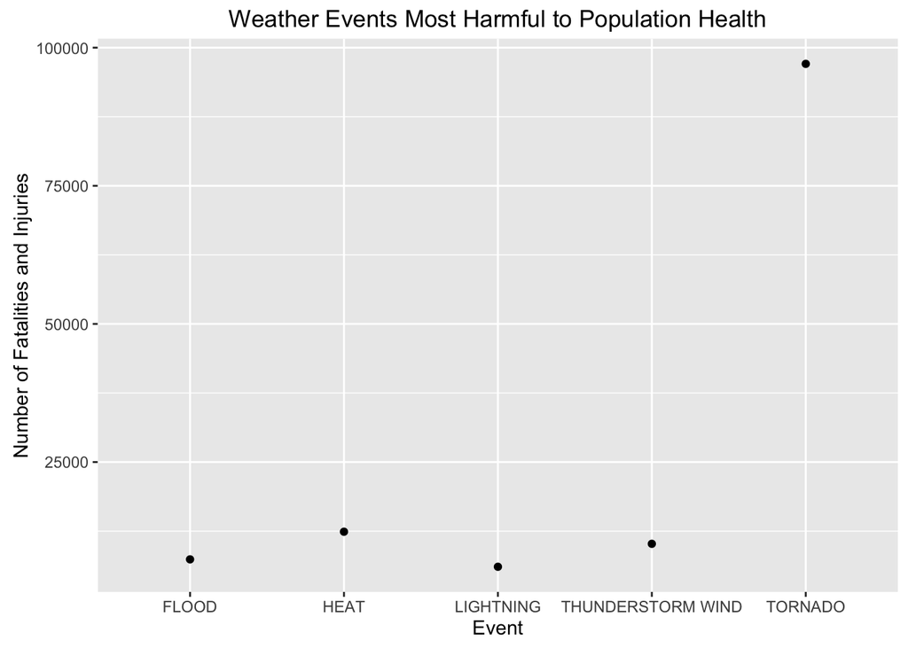

```r
health <- ggplot(head(healthEvents,5), aes(cleanEVTYPE, HEALTH))
health <- health + geom_point() + labs(x = "Event", y =
                                "Number of Fatalities and Injuries", title =
                                "Weather Events Most Harmful to Population Health")
print(health)
```

Here is a plot of the top five events with the greatest ecconomic consequences:

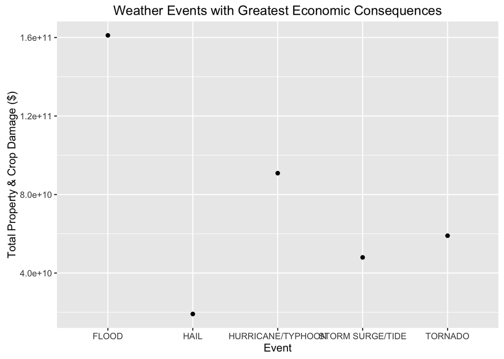

```r
economic <- ggplot(head(economicEvents,5), aes(cleanEVTYPE, DMG))
economic <- economic + geom_point() + labs(x = "Event", y =
                                        "Total Property & Crop Damage ($)", title =
                                        "Weather Events with Greatest Economic Consequences")
print(economic)
```

Both *TORNADO* and *FLOOD* are in the top five weather events with both the greatest impact on population health and economic damage.